# coordinated_ordering9

GroupB

28/07/2020

```r
library(kableExtra)
library(knitr)
```

# Data preparation

```r
library(readxl)

product_data <- read_excel("Data_ordering.xlsx",sheet = "product data")
box_data <- read_excel("Data_ordering.xlsx",sheet = "box data")
#rack data
Total_racks=8
levels_per_rack=4
rack_length= 6000
rack_width=1750
rack_height=300
```

## Convert to Boxes

Convert demand $d_i$, quantity $q_i$ and unit price $p_i$ all from part $i$ to box $bc_i$ which is the capacity of a box for part $i$.

Demand for box with part $i$ .
$$y_i=\frac {d_i*262}{bc_i}$$

Price for box with material $i$ .
$$pr_i= bc_i \cdot p_i$$

$y_i = demand\_per\_year \\ ,$ $pr_i = box\_cost=$ value of box

```r
product_data$demand_per_year= ceiling((product_data$`demand per day` *262)/ product_data$`pieces/box`)

product_data$box_cost= product_data$`pieces/box` * product_data$price

product_data
```

| material ID | demand per day | box ID | pieces/box | price | demand_per_year | box_cost |
| --- | --- | --- | --- | --- | --- | --- |
| 7305667+74 | 12 | 6203060 | 45 | 1.51 | 70 | 67.95 |
| 7305669+77 | 30 | 6203059 | 15 | 7.62 | 524 | 114.30 |
| 7305670+77 | 30 | 6203059 | 15 | 1.62 | 524 | 24.30 |
| 7305673+76 | 30 | 6203059 | 16 | 1.51 | 492 | 24.16 |
| 7305674+76 | 30 | 6203059 | 16 | 1.51 | 492 | 24.16 |
| 7305817+74 | 60 | 6203060 | 16 | 4.55 | 983 | 72.80 |
| 7305819+79 | 30 | 6203059 | 6 | 11.13 | 1310 | 66.78 |
| 7305820+79 | 30 | 6203059 | 6 | 2.86 | 1310 | 17.16 |
| 7305823+73 | 30 | 6203059 | 30 | 4.05 | 262 | 121.50 |
| 7305824+73 | 30 | 6203059 | 30 | 2.56 | 262 | 76.80 |

[output cut: 52 more lines]

```r
product_data <- merge(product_data, box_data[,c("box ID", "ordering cost (€)")], by = "box ID")

colnames(product_data)[8] <- "ordering_cost"
product_data
```

| box ID | material ID | demand per day | pieces/box | price | demand_per_year | box_cost | ordering_cost |
| --- | --- | --- | --- | --- | --- | --- | --- |
| 3103147 | 7348808+73 | 30 | 18 | 2.58 | 437 | 46.44 | 50 |
| 3103147 | 7346592+72 | 360 | 64 | 1.99 | 1474 | 127.36 | 50 |
| 3104147 | 7455691+71 | 24 | 20 | 4.39 | 315 | 87.80 | 45 |
| 3104147 | 7455692+71 | 24 | 20 | 4.39 | 315 | 87.80 | 45 |
| 3106410 | 7305865+77 | 30 | 14 | 3.15 | 562 | 44.10 | 60 |
| 3108210 | 7306005+73 | 6 | 20 | 1.50 | 79 | 30.00 | 65 |
| 3108210 | 7308013+79 | 30 | 13 | 19.46 | 605 | 252.98 | 65 |
| 3108210 | 7308014+79 | 30 | 13 | 1.58 | 605 | 20.54 | 65 |
| 3108210 | 7455688+72 | 24 | 24 | 10.70 | 262 | 256.80 | 65 |
| 3108210 | 7455633+73 | 24 | 8 | 24.57 | 786 | 196.56 | 65 |

[output cut: 52 more lines]

## Lane Occupation

$b_i=$ sorting column lenght or width.This determines the lane width

$b_i^{-1}=$if sorted by length then the value is width and vice versa, used for rack lenght.

Add $b_i$ and $b_i^{-1}$ to product_data table

```r
# constraints #####################################
# this can be formulated more elegantly, but it works and that suffices
b_sorting <- double(length(product_data$`box ID`))
b_not_sorting <-double(length(product_data$`box ID`))

for(j in 1: length(box_data$`box ID`)){
  for (k in 1:length(product_data$`box ID`)) {
    if(box_data$`box ID`[j]==product_data$`box ID`[k]){

      if(box_data$sorting[j]=="width"){
        b_sorting[k] <- box_data$width[j]
        b_not_sorting[k]<- box_data$length[j]

      }else{
        b_sorting[k] <- box_data$length[j]
        b_not_sorting[k]<- box_data$width[j]
      }
    }
  }

}

product_data$b_sorting <- b_sorting
product_data$b_not_sorting <- b_not_sorting
product_data
```

| box ID | material ID | demand per day | pieces/box | price | demand_per_year | box_cost | ordering_cost | b_sorting | b_not_sorting |
| --- | --- | --- | --- | --- | --- | --- | --- | --- | --- |
| 3103147 | 7348808+73 | 30 | 18 | 2.58 | 437 | 46.44 | 50 | 198 | 297 |
| 3103147 | 7346592+72 | 360 | 64 | 1.99 | 1474 | 127.36 | 50 | 198 | 297 |
| 3104147 | 7455691+71 | 24 | 20 | 4.39 | 315 | 87.80 | 45 | 396 | 297 |
| 3104147 | 7455692+71 | 24 | 20 | 4.39 | 315 | 87.80 | 45 | 396 | 297 |
| 3106410 | 7305865+77 | 30 | 14 | 3.15 | 562 | 44.10 | 60 | 594 | 396 |
| 3108210 | 7306005+73 | 6 | 20 | 1.50 | 79 | 30.00 | 65 | 596 | 794 |
| 3108210 | 7308013+79 | 30 | 13 | 19.46 | 605 | 252.98 | 65 | 596 | 794 |
| 3108210 | 7308014+79 | 30 | 13 | 1.58 | 605 | 20.54 | 65 | 596 | 794 |
| 3108210 | 7455688+72 | 24 | 24 | 10.70 | 262 | 256.80 | 65 | 596 | 794 |
| 3108210 | 7455633+73 | 24 | 8 | 24.57 | 786 | 196.56 | 65 | 596 | 794 |

[output cut: 52 more lines]

E.g Using box_ID 6203060, sorted by length $b_i=396$, $b_i^{-1}=297$ Also for material ID 7305667+74 with $q_i=214$ therefore, $rack_{length}=6000 \\$

*1.* Number of boxes in a lane:

$$n_i=\frac {rack_{length}}{b_i^{-1}}=\frac {6000}{297}=20.20=20boxes$$

*2.* How many lanes part $i$ will occupy if you order some number of boxes

$$lane_i=\frac {q_i}{n_i}\\lane_i=q_i \cdot \frac {b_i^{-1}}{rack_{length}}=214 \cdot \frac {297}{6000}=10.593= 11 \space lanes$$

$$lane_i= \left\lceil\frac{b^{-1}_i \cdot q_i}{rl} \right \rceil$$

```r
lane <- ceiling(product_data$eoq * (product_data$b_not_sorting/rack_length))
lane
```

```
## numeric(0)
```

3. Do we meet the capacity contraint?

*3.* Total number of lanes constraints

Collapsing Rack 4 levels in a rack and joining the 8 racks to become 1 level.

Total rack width available:

$$rack_{total_{Width}}=(rack_{width} \times 4 \times 8)$$

```r
rack_total_width <-51200  #rack_width * 4 * 8
rack_total_width #56000
```

```
## [1] 51200
```

```r
lane.min <- ceiling(product_data$eoq.min * product_data$b_not_sorting / rack_length)
lane.max <- ceiling(product_data$eoq.max * product_data$b_not_sorting / rack_length)

# total rack width

rack_total_width <- 51200 # rack_width * 4 * 8
```

Overflow in mm

$$[\sum_{i=1}^n lane_i \cdot b_i]- rack_{{total}_{width}}$$
relative overflow in %

$$\frac{[\sum_{i=1}^n lane_i \cdot b_i]- rack_{{total}_{width}}} {rack_{{total}_{width}} } \cdot 100$$

```r
# overflow in mm
sum(lane.min*product_data$b_sorting) - rack_total_width
```

```
## [1] -51200
```

```r
sum(lane.max*product_data$b_sorting) - rack_total_width
```

```
## [1] -51200
```

```r
# relative overflow in %
(sum(lane.min*product_data$b_sorting) - rack_total_width)/rack_total_width*100
```

```
## [1] -100
```

```r
(sum(lane.max*product_data$b_sorting) - rack_total_width)/rack_total_width*100
```

```
## [1] -100
```

Please note the coefficients are are different for every ith item except racklength which is the same for all items.Also the left and right hand side of the equation need to be in mm.
$$\sum_{i=1}^{n=62}lane_i \cdot b_i\le rack_{Total_{width}} \\ \sum_{i=1}^{n=62} q_i \cdot \frac {b_i^{-1} \cdot b_i}{rack_{length}} \le rack_{Total_{width}} \quad \quad (1)$$

```r
#get the with of the lanes in mm
rack_width_occupied=sum(lane.min*product_data$b_sorting)
rack_width_occupied
```

```
## [1] 0
```

```r
if(rack_width_occupied <= rack_total_width){
  print(paste0("Capacity constraint fulfilled: ", rack_width_occupied, "<=",rack_total_width))

}else {
  violated <- rack_width_occupied - rack_total_width
  print(paste0("Capacity constraint violated by: ",violated ))
}
```

```
## [1] "Capacity constraint fulfilled: 0<=51200"
```

Using our example to get number of the total width i.e (summation of lanes) in $mm$: Summation of lanes can simply be:
$$lanes_i \cdot b_i= 10.593 \cdot 396=4194.828$$
Using equation (1) to prove this concept.

$$214 \cdot \frac {396 \cdot 297}{6000}=4194.828 \\ b_i= \frac {4194.828}{10.593}=396$$

4. Adjust Q by reducing it:

$\frac {y_i}{q_i}=$ no of orders for part $i \\$ $\frac {q_i}{2}=$ average inventory for part $i$

# Separate Ordering (SO)

$c_i^{or}=$ ordering cost for part $i ,\space$

$c_i^{sh}=$ stock holding cost rate based on unit price $p_i$ and interest rate $h, \qquad$. $c_i^{sh}=pr_i \cdot h$

calculate EOQ for each part i:
$$q_i^* = \sqrt \frac {2 \cdot y_i \cdot (c_i^{or}+c^{-or})} {pr_i \cdot h}$$

Min EOQ, used in starting feasible solution.
$$q_i^* = \sqrt \frac {2 \cdot y_i \cdot (c_i^{or})} {pr_i \cdot h}$$

## EOQ modelling

```r
#dei= demand_per_year, cori= ordering cost for box i
#cord= ordering cost, pri= box cost, h= interest rate

# directly vectorized
so_eoq_fun <- Vectorize(function(dei,cori,cord,pri,h){
  eoq<- sqrt((2*dei*(cori+cord))/(pri*h))
  return(eoq)
})

# maximum EOQ provided there is no coordination of ordering cycles (i.e., cord are not shared among parallely ordered items)
vec_so_eoq_fun.max <- so_eoq_fun(dei = product_data$demand_per_year,cori=product_data$ordering_cost,cord=1500,pri=product_data$box_cost,h=0.10)
# minimum EOQ disregarding common ordering cost cord
vec_so_eoq_fun.min <- so_eoq_fun(dei = product_data$demand_per_year,cori=product_data$ordering_cost,cord=0,pri=product_data$box_cost,h=0.10)

product_data$eoq.min <- round(vec_so_eoq_fun.min)
product_data$eoq.max <- round(vec_so_eoq_fun.max)
product_data
```

| box ID | material ID | demand per day | pieces/box | price | demand_per_year | box_cost | ordering_cost | b_sorting | b_not_sorting | eoq.min | eoq.max |
| --- | --- | --- | --- | --- | --- | --- | --- | --- | --- | --- | --- |
| 3103147 | 7348808+73 | 30 | 18 | 2.58 | 437 | 46.44 | 50 | 198 | 297 | 97 | 540 |
| 3103147 | 7346592+72 | 360 | 64 | 1.99 | 1474 | 127.36 | 50 | 198 | 297 | 108 | 599 |
| 3104147 | 7455691+71 | 24 | 20 | 4.39 | 315 | 87.80 | 45 | 396 | 297 | 57 | 333 |
| 3104147 | 7455692+71 | 24 | 20 | 4.39 | 315 | 87.80 | 45 | 396 | 297 | 57 | 333 |
| 3106410 | 7305865+77 | 30 | 14 | 3.15 | 562 | 44.10 | 60 | 594 | 396 | 124 | 631 |
| 3108210 | 7306005+73 | 6 | 20 | 1.50 | 79 | 30.00 | 65 | 596 | 794 | 59 | 287 |
| 3108210 | 7308013+79 | 30 | 13 | 19.46 | 605 | 252.98 | 65 | 596 | 794 | 56 | 274 |
| 3108210 | 7308014+79 | 30 | 13 | 1.58 | 605 | 20.54 | 65 | 596 | 794 | 196 | 960 |
| 3108210 | 7455688+72 | 24 | 24 | 10.70 | 262 | 256.80 | 65 | 596 | 794 | 36 | 179 |
| 3108210 | 7455633+73 | 24 | 8 | 24.57 | 786 | 196.56 | 65 | 596 | 794 | 72 | 354 |

[output cut: 52 more lines]

## Constrained EOQ optimization

$$min \rightarrow (\sum_{i=1}^{n=62}c^{-or} + \sum_{i=1}^{n=62} \frac {y_i}{q_i} \cdot c_i^{or}) + (h \cdot \sum_{i=1}^{n=62} \frac {q_i}{2}\cdot pr_i )$$
Subject to:
$$\sum_{i=1}^{n=62} q_i \cdot \frac {b_i^{-1} \cdot b_i}{rack_{length}} \le rack_{Total_{width}}$$

```r
library(ROI)
library(ROI.plugin.alabama)

n <- length(product_data$`material ID`) #number of materials
cori <- product_data$ordering_cost   #ordering cost for each items
cord <-  1500    #ordering cost whenever there is an order
dei <- product_data$demand_per_year
h<-0.10
box_cost <- product_data$box_cost #pri

# objective function --> I dropped the 1500*62 as it is not decision relevant
obj.fun <- function(q, d= dei, c.or = cori, c.h = h*box_cost  ) (sum((dei/q)*c.or)+ sum(c.h*(q/2)))
# benchmarks
obj.fun(product_data$eoq.max)
```

```
## [1] 79279.71
```

```r
obj.fun(product_data$eoq.min)
```

```
## [1] 31501.53
```

```r
# constraint function --> also contains the ceiling of lanes and a sum was missing
const.fun <- function(q, bns = product_data$b_not_sorting, bs = product_data$b_sorting, rl = rack_length) {
  sum(bs * ceiling( bns * q / rl))
  }

const.fun(product_data$eoq.max)
```

```
## [1] 1224292
```

```r
const.fun(product_data$eoq.min)
```

```
## [1] 269894
```

```r
# try to figure out a freasible starting solution
const.fun(product_data$eoq.min/10) -  rack_total_width
```

```
## [1] -10386
```

```r
qopt <- OP(
  objective = F_objective(F=obj.fun ,n=n),
  types = rep("C",n),
  bounds = V_bound(ub= product_data$eoq.min , lb= rep(1, n)),
  constraints = F_constraint(F=const.fun,
                             dir="<=",
                             rhs = rack_total_width)
)

#This shows that minimum EOQ is too big and therefore will not meet the rack space constraint.
const.fun(min(product_data$eoq.max))#366272
```

```
## [1] 313556
```

```r
const.fun(min(product_data$eoq.max)/8)# 61428  still > 56000
```

```
## [1] 52716
```

```r
const.fun(min(product_data$eoq.max)/8.7)#52716 < 56000
```

```
## [1] 52716
```

```r
const.fun(min(product_data$eoq.max)/10)# 33098 < 56000 is much lower but this can still be the starting value
```

```
## [1] 33098
```

```r
round(min(product_data$eoq.max)/10) #15
```

```
## [1] 15
```

```r
copt_sol <- ROI_solve(qopt, start = rep(min(product_data$eoq.max)/10,n), solver = "alabama" )
# always check whether the algorithm converged
copt_sol# The objective value is: 101625.9
```

```
## Optimal solution found.
## The objective value is: 1.092799e+05
```

```r
# solution
copt_sol$solution #vector of optimal Quantity that meets the space constraints and minimizes the Obj function.
```

```
##  [1] 19.21277 19.98082 18.10408 18.10408 20.07066 16.50759 19.87768 20.22267
##  [9] 18.02317 20.07752 20.34807 16.36283 18.50350 20.28845 15.09718 20.37517
## [17] 20.21815 19.93476 20.25461 18.49918 15.51115 20.21815 19.03311 20.33883
## [25] 20.33375 18.30819 18.16358 17.33315 19.59133 17.14746 17.15822 18.92858
## [33] 18.91119 20.31552 17.49555 16.37103 20.20202 20.20152 20.19630 20.09364
## [41] 19.85988 17.04693 16.50265 17.29302 17.36417 20.09317 17.03609 16.63235
## [49] 15.59037 19.53891 17.19712 18.05721 16.17151 15.52704 19.54321 16.15005
## [57] 17.44414 19.59295 20.38314 17.61382 14.94486 14.83263
```

```r
round(copt_sol$solution)
```

```
##  [1] 19 20 18 18 20 17 20 20 18 20 20 16 19 20 15 20 20 20 20 18 16 20 19 20 20
## [26] 18 18 17 20 17 17 19 19 20 17 16 20 20 20 20 20 17 17 17 17 20 17 17 16 20
## [51] 17 18 16 16 20 16 17 20 20 18 15 15
```

```r
copt_sol$objval #101625.9
```

```
## [1] 109279.9
```

```r
const.fun(copt_sol$solution)#55884
```

```
## [1] 51132
```

```r
const.fun(floor(copt_sol$solution))#55092
```

```
## [1] 50340
```

```r
obj.fun(copt_sol$solution)#101625.9
```

```
## [1] 109279.9
```

```r
obj.fun(floor(copt_sol$solution))#104639.7  rounded q values
```

```
## [1] 112079.8
```

removing waste of 150 for every 32 levels

```r
rack_total_width <- 51200
qopt1 <- OP(
  objective = F_objective(F=obj.fun ,n=n),
  types = rep("C",n),
  bounds = V_bound(ub= product_data$eoq.min , lb= rep(1, n)),
)

copt_sol1 <- ROI_solve(qopt, start = rep(min(product_data$eoq.max)/10,n), solver = "alabama" )
# always check whether the algorithm converged
copt_sol1$objval
```

```
## [1] 109279.9
```

## Compare results

Remember, $1500*62$ was dropped from the objective function as it is not decision relevant.

```r
obj.fun <- function(q, d= dei, c.or = cori, c.h = h*box_cost  ) (1500*62)+(sum((dei/q)*c.or)+ sum(c.h*(q/2)))
obj.fun(product_data$eoq.max)#172279.7
```

```
## [1] 172279.7
```

```r
const.fun(copt_sol$solution)#55884
```

```
## [1] 51132
```

```r
const.fun(floor(copt_sol$solution))#55092  we rounded down to avoid exceeding capacity
```

```
## [1] 50340
```

```r
obj.fun(copt_sol$solution)#194625.9
```

```
## [1] 202279.9
```

```r
obj.fun(floor(copt_sol$solution))#197639.7 rounded q values
```

```
## [1] 205079.8
```

```r
# demand vs quantity

product_data$`demand per day`
```

```
##  [1]  30 360  24  24  30   6  30  30  24  24  24   6  24  30  30  30  30  60  30
## [20]  30  30  30  30  30  30   6   6   6  60   6   6  30  30  30   6  12  30  30
## [39]  30  30  60   6   6   6   6  30   6   6   6  30  24  30   6   6  30   6  30
## [58]  60  30  30  30  30
```

```r
product_data$demand_per_year  #
```

```
##  [1]  437 1474  315  315  562   79  605  605  262  786  786   79  262  655 1310
## [16]  524  492  983  524  246 1310  492  262  655  655  175  175  131  328  105
## [31]  105  246  262  655  131   70  524  524  715  437  983   99   79  121  121
## [46]  437   99   79   53  492  175  262   79   53  492   79  219  524  983  219
## [61] 1572 1572
```

```r
floor(copt_sol$solution)
```

```
##  [1] 19 19 18 18 20 16 19 20 18 20 20 16 18 20 15 20 20 19 20 18 15 20 19 20 20
## [26] 18 18 17 19 17 17 18 18 20 17 16 20 20 20 20 19 17 16 17 17 20 17 16 15 19
## [51] 17 18 16 15 19 16 17 19 20 17 14 14
```

Plot EOQ cost vs cost

cost function per item
$$C(q_i) \rightarrow (c^{-or} + \frac {y_i}{q_i} \cdot c_i^{or}) + (h \cdot \frac {q_i}{2}\cdot pr_i )$$

```r
#EOQ cost

#with no constraint
paste("with no capacity constraint, cost is  €", round(obj.fun(product_data$eoq.max)))#173539.2
```

```
## [1] "with no capacity constraint, cost is  \200 172280"
```

```r
#with constraint
paste("with capacity constraint, cost is  €",round(obj.fun(copt_sol$solution))) #202866.4
```

```
## [1] "with capacity constraint, cost is  \200 202280"
```

```r
paste("It costs €",round(obj.fun(copt_sol$solution))-round(obj.fun(product_data$eoq.max))," extra due to lack of capacity")
```

```
## [1] "It costs \200 30000  extra due to lack of capacity"
```

The above result shows that If there is no capacity constraint, the cost will be lower.

```r
x.val <- seq.int(1,62, length.out = 62)

cost.fun <- function(q, d= dei, c.or = cori, c.h = h*box_cost  ){
  (1500 +(dei/q)*c.or)+ (c.h*(q/2))
}

y.vec.no.const <- cost.fun(q=product_data$eoq.max)
y.vec.yes.const<- cost.fun(copt_sol$solution)

paste(length(which((round(y.vec.yes.const)>round(y.vec.no.const))==TRUE))," Items costs more when capacity becomes a problem")
```

```
## [1] "26  Items costs more when capacity becomes a problem"
```

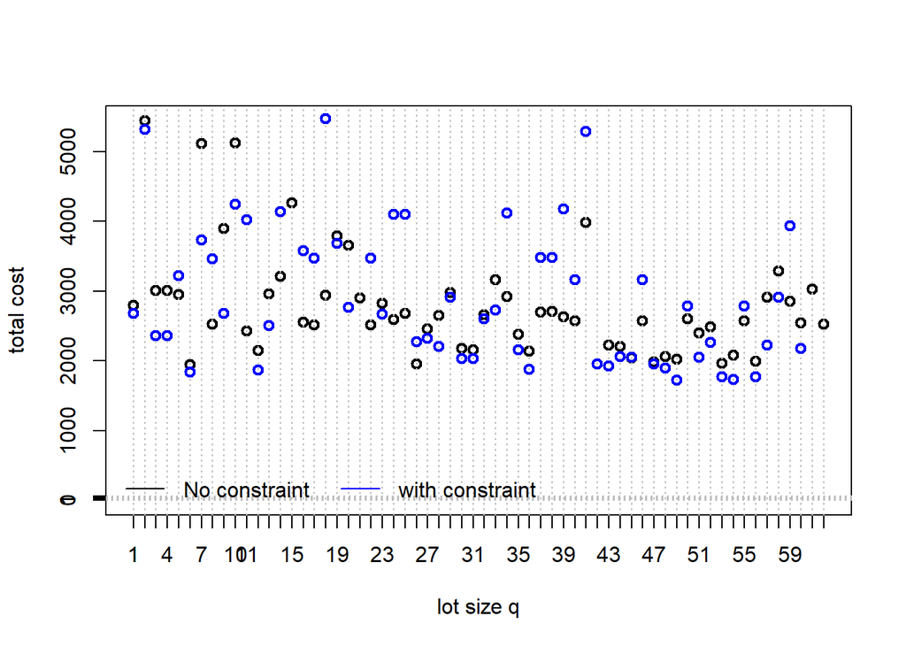

```r
#par(mfrow=c(1,1))
{
  plot(x.val,round(y.vec.no.const), xlab ="lot size q", ylab = "total cost", type = "p", lwd =2, ylim=c(12,max(y.vec.no.const)), xaxp=c(1, 10, 1) )
  axis(1, 1:62)
axis(2, 1:62)
abline(h=1:62, v=1:62, col="gray", lty=3)

points(x=x.val,y=round(y.vec.yes.const),lwd=2, col="blue")

legend("bottomleft",lty = c(1,1),col = c("black","blue"), legend = c("No constraint","with constraint"), bty="n" , horiz = T)
}
```

# Joint Ordering (JO)

Using Joint replenishment problem

Assumptions:

- One supplier with outbound storage.
- $i=\{1,...,n\}$ products
- Demand rates: $de_i$
- Stock_holding cost rates: $c_i^{sh}$
- Specific setup costs: $c_i^{or}$
- General setup costs: $c^{-or}$
- Cycle time of product $i$: $T_i$

```r
n <- length(product_data$`box ID`)
c.or0 <- cord
c.or <- product_data$ordering_cost
#H.vec <- 0.5 * dei * c.sh
# based on the previous definition, I think this should be the vector of holding cost multipliers
H.vec <- 0.1 * product_data$box_cost * dei * 0.5
```

## Objective Function with no capacity constraint

- $B=$basic cycle time
- $H_i=0.5 \cdot y_i \cdot c_i^{sh}$
- $H_0=0$ Holding cost multiplier are $H_0 \space and \space H_i$
- $$C(m_i B)=\sum_{i=0}^n (\frac {c_i^{or}}{m_i \cdot B}+H_i \cdot m_i \cdot B) == \frac {c_o^{or}}{B}+ \sum_{i=1}^n (\frac {c_i^{or}}{m_i \cdot B}+H_i \cdot m_i \cdot B) \\ subject \space to: \quad \quad \quad \quad \quad \quad \quad \quad \quad \\ m_i \ge m_0 \quad \forall i >0 \\m_i \in \mathbb N \qquad \forall i$$

–> an important side note is that the JRP is basically a quite standard EOQ problem which uses the substitution $T_i = \frac{q_i}{y_i}$, i.e., $q_i = T_i \cdot y_i$. Then, you substitute $T_i = m_i \cdot B$ ans result in the JRP (adding the common ordering cost).

```r
jrp.obj.fun <- function(m , B, cor, Hvec, cor0) cor0/B + sum(cor/B/m) + sum(Hvec*B*m)
```

- *Cycle Time*

we determine $T_i=\sqrt (\frac {c_i^{or}}{H_i})$ and $T^C=\frac {\sum_{j=0}^{i´} c_j^{or}}{\sum_{j=0}^{i´}H_j}$

```r
# calculate cycle times
T.vec <- sqrt(c.or/H.vec)
# order products
reo.id <- order(T.vec)
T.vec <- T.vec[reo.id]
c.or <- c.or[reo.id]
H.vec <- H.vec[reo.id]

cost_cycle.mat <- t(cbind(c.or,H.vec,T.vec))
costs.cycle <- data.frame(cost_cycle.mat)
colnames(costs.cycle) <- reo.id
rownames(costs.cycle) <- c(  "$c_i^{or}$" ,"$H_i$","$T_i$" )
kable(costs.cycle ,"pandoc", row.names = T)
```

|  | 2 | 10 | 7 | 15 | 9 | 41 | 58 | 19 | 20 | 3 | 4 | 57 | 59 | 14 | 5 | 1 | 33 | 61 | 13 | 29 | 18 | 50 | 34 | 21 | 55 | 60 | 23 | 52 | 38 | … |
| --- | --- | --- | --- | --- | --- | --- | --- | --- | --- | --- | --- | --- | --- | --- | --- | --- | --- | --- | --- | --- | --- | --- | --- | --- | --- | --- | --- | --- | --- | --- |
| $c_i^{or}$ | 50.0000000 | 65.0000000 | 65.0000000 | 80.0000000 | 65.0000000 | 75.0000000 | 50.0000000 | 80.0000000 | 80.0000000 | 45.0000000 | 45.0000000 | 50.0000000 | 50.0000000 | 80.0000000 | 60.0000000 | 50.0000000 | 80.0000000 | 70.0000000 | 65.0000000 | 80.0000000 | 80.000000 | 50.0000000 | 80.0000000 | 80.0000000 | 50.0000000 | 50.0000000 | 80.0000000 | 50.0000000 | 75.0000000 | … |
| $H_i$ | 9386.4320000 | 7724.8080000 | 7652.6450000 | 4374.0900000 | 3364.0800000 | 3578.1200000 | 1925.7000000 | 2994.6600000 | 2652.8640000 | 1382.8500000 | 1382.8500000 | 1214.1360000 | 1108.8240000 | 1678.1100000 | 1239.2100000 | 1014.7140000 | 1591.6500000 | 1355.8500000 | 1254.4560000 | 1243.7760000 | 1195.328000 | 736.0320000 | 1163.2800000 | 1123.9800000 | 692.7360000 | 658.3140000 | 1006.0800000 | 589.5000000 | 844.9500000 | … |
| $T_i$ | 0.0729852 | 0.0917303 | 0.0921618 | 0.1352387 | 0.1390028 | 0.1447782 | 0.1611353 | 0.1634448 | 0.1736551 | 0.1803926 | 0.1803926 | 0.2029324 | 0.2123507 | 0.2183407 | 0.2200408 | 0.2219797 | 0.2241926 | 0.2272182 | 0.2276297 | 0.2536144 | 0.258703 | 0.2606374 | 0.2622424 | 0.2667876 | 0.2686588 | 0.2755932 | 0.2819868 | 0.2912347 | 0.2979306 | … |

```r
library(kableExtra)
# calculate T^2 and cumu. cost shares
res.mat <- t(cbind(c.or/H.vec,(c.or0 + cumsum(c.or))/cumsum(H.vec)))
df <- data.frame(res.mat)
colnames(df) <- reo.id
rownames(df) <- c(  "$T_i^2$" ,"$T^C$"  )
kable(df,"pandoc", row.names = T)
```

|  | 2 | 10 | 7 | 15 | 9 | 41 | 58 | 19 | 20 | 3 | 4 | 57 | 59 | 14 | 5 | 1 | 33 | 61 | 13 | 29 | 18 | 50 | 34 | 21 | 55 | 60 | 23 | 52 | 38 | … |
| --- | --- | --- | --- | --- | --- | --- | --- | --- | --- | --- | --- | --- | --- | --- | --- | --- | --- | --- | --- | --- | --- | --- | --- | --- | --- | --- | --- | --- | --- | --- |
| $T_i^2$ | 0.0053268 | 0.0084144 | 0.0084938 | 0.0182895 | 0.0193218 | 0.0209607 | 0.0259646 | 0.0267142 | 0.0301561 | 0.0325415 | 0.0325415 | 0.0411815 | 0.0450928 | 0.0476727 | 0.0484179 | 0.0492750 | 0.0502623 | 0.0516281 | 0.0518153 | 0.0643203 | 0.0669272 | 0.0679318 | 0.0687711 | 0.0711756 | 0.0721776 | 0.0759516 | 0.0795165 | 0.0848176 | 0.0887626 | … |
| $T^C$ | 0.1651320 | 0.0943824 | 0.0678407 | 0.0604023 | 0.0561503 | 0.0526605 | 0.0513079 | 0.0495115 | 0.0483353 | 0.0478503 | 0.0473943 | 0.0472359 | 0.0471872 | 0.0472033 | 0.0472325 | 0.0472718 | 0.0473595 | 0.0474636 | 0.0475596 | 0.0479182 | 0.0483013 | 0.0485419 | 0.0489263 | 0.0493275 | 0.0495786 | 0.0498512 | 0.0503126 | 0.0506241 | 0.0511114 | … |

$$B=\sqrt \frac {\sum_{i=0}^n \frac {c_i^{or}}{m_i}}{\sum_{i=0}^n m_i \cdot H_i}$$

```r
# identify break
which(res.mat[1,] > res.mat[2,])# break occured after 13
```

```
##  [1] 14 15 16 17 18 19 20 21 22 23 24 25 26 27 28 29 30 31 32 33 34 35 36 37 38
## [26] 39 40 41 42 43 44 45 46 47 48 49 50 51 52 53 54 55 56 57 58 59 60 61 62
```

```r
id.comb <- min(which(res.mat[1,] > res.mat[2,])) - 1 #3
id.comb
```

```
## [1] 13
```

```r
# calculate B
B <- min(T.vec) #0.01955164
# solution with m - integers #######################
m.vec.int <- round(T.vec/B,0)

m.vec.int[1:id.comb] <- 1
# re-optimize B for fixed m.vec
B.int <- sqrt(sum(c.or/m.vec.int)/sum(m.vec.int*H.vec))#0.02014868
# total cost
c.cost.int <- jrp.obj.fun( m = m.vec.int, B=B.int, cor = c.or,Hvec=H.vec, cor0 = c.or0)#192606
df <- data.frame(rbind(round(T.vec/B,2), round(T.vec/B), m.vec.int))
colnames(df) <- reo.id
rownames(df) <- c("$m_i=\\frac{T_i}{B}$" ,"$[m_i]$", "$[\\tilde{m}_i]$" )
kable(df,"pandoc", row.names = T)
```

|  | 2 | 10 | 7 | 15 | 9 | 41 | 58 | 19 | 20 | 3 | 4 | 57 | 59 | 14 | 5 | 1 | 33 | 61 | 13 | 29 | 18 | 50 | 34 | 21 | 55 | 60 | 23 | 52 | 38 | … |
| --- | --- | --- | --- | --- | --- | --- | --- | --- | --- | --- | --- | --- | --- | --- | --- | --- | --- | --- | --- | --- | --- | --- | --- | --- | --- | --- | --- | --- | --- | --- |
| $m_i=\frac{T_i}{B}$ | 1 | 1.26 | 1.26 | 1.85 | 1.9 | 1.98 | 2.21 | 2.24 | 2.38 | 2.47 | 2.47 | 2.78 | 2.91 | 2.99 | 3.01 | 3.04 | 3.07 | 3.11 | 3.12 | 3.47 | 3.54 | 3.57 | 3.59 | 3.66 | 3.68 | 3.78 | 3.86 | 3.99 | 4.08 | … |
| $[m_i]$ | 1 | 1.00 | 1.00 | 2.00 | 2.0 | 2.00 | 2.00 | 2.00 | 2.00 | 2.00 | 2.00 | 3.00 | 3.00 | 3.00 | 3.00 | 3.00 | 3.00 | 3.00 | 3.00 | 3.00 | 4.00 | 4.00 | 4.00 | 4.00 | 4.00 | 4.00 | 4.00 | 4.00 | 4.00 | … |
| $[\tilde{m}_i]$ | 1 | 1.00 | 1.00 | 1.00 | 1.0 | 1.00 | 1.00 | 1.00 | 1.00 | 1.00 | 1.00 | 1.00 | 1.00 | 3.00 | 3.00 | 3.00 | 3.00 | 3.00 | 3.00 | 3.00 | 4.00 | 4.00 | 4.00 | 4.00 | 4.00 | 4.00 | 4.00 | 4.00 | 4.00 | … |

The order quantities are given by multiplying the cycle times $T_i$ with demand rates $y_i$, i.e. $q_i = T_i \cdot y_i$ such that

```r
dei <- dei[reo.id]
df <- data.frame(rbind( m.vec.int, round(m.vec.int*B, 2), round(m.vec.int*B*dei, 2) ))
colnames(df) <- reo.id
rownames(df) <- c("$[\\tilde{m}_i]$", "$T_i$", "$q_i$" )
kable(df,"pandoc", row.names = T)
```

|  | 2 | 10 | 7 | 15 | 9 | 41 | 58 | 19 | 20 | 3 | 4 | 57 | 59 | 14 | 5 | 1 | 33 | 61 | 13 | 29 | 18 | 50 | 34 | 21 | 55 | 60 | 23 | 52 | 38 | … |
| --- | --- | --- | --- | --- | --- | --- | --- | --- | --- | --- | --- | --- | --- | --- | --- | --- | --- | --- | --- | --- | --- | --- | --- | --- | --- | --- | --- | --- | --- | --- |
| $[\tilde{m}_i]$ | 1.00 | 1.00 | 1.00 | 1.00 | 1.00 | 1.00 | 1.00 | 1.00 | 1.00 | 1.00 | 1.00 | 1.00 | 1.00 | 3.00 | 3.00 | 3.00 | 3.00 | 3.00 | 3.00 | 3.00 | 4.00 | 4.00 | 4.00 | 4.00 | 4.00 | 4.00 | 4.00 | 4.00 | 4.00 | … |
| $T_i$ | 0.07 | 0.07 | 0.07 | 0.07 | 0.07 | 0.07 | 0.07 | 0.07 | 0.07 | 0.07 | 0.07 | 0.07 | 0.07 | 0.22 | 0.22 | 0.22 | 0.22 | 0.22 | 0.22 | 0.22 | 0.29 | 0.29 | 0.29 | 0.29 | 0.29 | 0.29 | 0.29 | 0.29 | 0.29 | … |
| $q_i$ | 107.58 | 57.37 | 44.16 | 95.61 | 19.12 | 71.74 | 38.24 | 38.24 | 17.95 | 22.99 | 22.99 | 15.98 | 71.74 | 143.42 | 123.05 | 95.68 | 57.37 | 344.20 | 57.37 | 71.82 | 286.98 | 143.63 | 191.22 | 382.44 | 143.63 | 63.94 | 76.49 | 76.49 | 152.98 | … |

–> Now the question is: Is this feasible? –> no:

```r
q.vec <- m.vec.int*B*dei
const.fun(q.vec) > rack_total_width
```

```
## [1] TRUE
```

## Including capacity constraint

When you try to optimize the JRP directly, without introducing the substitution $T_i = m_i \cdot B$ you need to update the JRP function as follows

```r
library(ROI)
jrp.obj.fun2 <- function(Tvec, cor, Hvec, cor0) sum(cor0/Tvec) + sum(cor/Tvec) + sum(Hvec*Tvec)
# you need to initialize the parameters in the objective function --> Tvec is to be optimized over, the rest is given
jrp.obj.fun2 <- function(Tvec, cor=c.or, Hvec = H.vec, cor0 = c.or0) sum(cor0/Tvec) + sum(cor/Tvec) + sum(Hvec*Tvec)

qopt2 <- OP(
  objective = F_objective(F=jrp.obj.fun2 , n=62),
  types = rep("C",n),
  bounds = V_bound(ub= rep(30, 62), lb= rep(.001,62))
)

jrp.obj.fun2(m.vec.int*B)
```

```
## [1] 511643.4
```

```r
jrp.obj.fun2(rep(.00001,62))
```

```
## [1] 9724500001
```

```r
jrp.obj.fun2(rep(15,62))
```

```
## [1] 1208367
```

```r
# you don't need Alabama here as there is no constraint. Basically you can also optimize this problem by taking derivatives
copt_sol2 <- ROI_solve(qopt2, start = m.vec.int*B)
copt_sol2
```

```
## Optimal solution found.
## The objective value is: 1.519523e+05
```

```r
copt_sol2$solution
```

```
##  [1] 0.4063670 0.4501050 0.4522240 0.6010157 0.6820617 0.6634549 0.8971623
##  [8] 0.7263596 0.7717417 1.0570060 1.0570072 1.1298829 1.1823300 0.9703281
## [15] 1.1219884 1.2359369 0.9963324 1.0760803 1.1169429 1.1270896 1.1497041
## [22] 1.4511717 1.1654254 1.1856357 1.4958263 1.5344552 1.2531816 1.6215258
## [29] 1.3652893 1.3716838 1.4107755 1.4634696 1.7875233 1.4311173 1.5870533
## [36] 1.4418001 1.5393302 1.5951506 1.5439084 1.5157012 1.5753462 1.7638244
## [43] 1.6304591 1.6304814 1.7409141 1.8812131 2.2845095 2.7760107 2.5077432
## [50] 2.3519777 3.0397243 2.4582625 2.5734214 2.5317848 3.2565722 3.4800606
## [57] 2.9570114 3.0661930 3.6340240 3.4201775 3.6051845 3.6450557
```

```r
m.vec.int*B*dei
```

```
##  [1] 107.58017  57.36636  44.15604  95.61060  19.12212  71.74444  38.24424
##  [8]  38.24424  17.95436  22.99033  22.99033  15.98376  71.74444 143.41590
## [15] 123.05303  95.68358  57.36636 344.19815  57.36636  71.81743 286.97776
## [22] 143.63485 191.22119 382.44239 143.63485  63.93502  76.48848  76.48848
## [29] 152.97695 152.97695 191.22119 208.73764  51.08963  71.81743 176.62416
## [36]  38.24424 159.47264 573.66358 159.47264 239.02649 191.22119 286.83179
## [43] 179.54356 179.54356  63.86204  57.36636  40.36081  27.07750  40.36081
## [50]  61.81845  27.07750  61.30756  40.87171  61.30756  46.12664  51.89247
## [57]  51.89247  79.48087  57.65830  72.25534  79.48087 140.49649
```

–> You should integrate the shelf capacity constraint –> I also recommmend to stick with the basic period approach

This is formally defined as
$$\sum_{i=1}^n b_i \cdot \left\lceil\frac{b^{-1}_i \cdot q_i}{rl} \right \rceil \leq \text{tot_rack_length}$$
Thus, with the substitution above, the left-hand side changes to
$$\sum_{i=1}^n b_i \cdot \left\lceil\frac{b^{-1}_i \cdot T_i \cdot y_i}{rl} \right \rceil = \sum_{i=1}^n b_i \cdot \left\lceil\frac{b^{-1}_i \cdot m_i \cdot B \cdot y_i}{rl} \right \rceil$$

Thus, you can change the constraint function quite easily

```r
# we reinitialize the vectors
n <- length(product_data$`box ID`)
c.or0 <- cord
c.or <- product_data$ordering_cost
dei <- product_data$demand_per_year
H.vec <- 0.1 * product_data$box_cost * dei * 0.5


bnotsort <- product_data$b_not_sorting
bsort <- product_data$b_sorting
copt_sol.solution <- copt_sol$solution



# calculate cycle times
T.vec <- sqrt(c.or/H.vec)
# order products
reo.id <- order(T.vec)
T.vec <- T.vec[reo.id]
c.or <- c.or[reo.id]
H.vec <- H.vec[reo.id]
bnotsort <- bnotsort[reo.id]
bsort <- bsort[reo.id]
copt_sol.solution <- copt_sol.solution[reo.id]
dei <- dei[reo.id]

const.fun2 <- function(m, B = B.start, y= dei, bns = bnotsort, bs = bsort, rl = rack_length) {
  sum(bs * ceiling( bns * m*B*y / rl))
  }
```

Then, you can use the original JRP function and update the model by including the capacity constraint. Therefore I recommend that you fix $B$ to some appropriate value based on the feasible solution above

$rack_{Totalwidth}=51200$

```r
#rack_total_width<-51200

#library(ROI.plugin.deoptim)

T.feas <- copt_sol.solution/dei
B.start <- min(T.feas)

jrp.obj.fun <- function(m , B = B.start, cor = c.or, Hvec = H.vec, cor0 = c.or0) cor0/B + sum(cor/B/m) + sum(Hvec*B*m)
jrp.obj.fun(m= rep(1, 62))
```

```
## [1] 609625.9
```

```r
const.fun2(m= rep(1, 62))
```

```
## [1] 28330
```

```r
qopt3 <- OP(
  objective = F_objective(F=jrp.obj.fun ,n=n),
  # now integer decision variables
  types = rep("C",n),
  bounds = V_bound(li = 1:n, ui = 1:n, ub= rep(50, n) , lb= rep(1, n)),
  constraints = F_constraint(F=const.fun2,
                             dir="<=",
                             rhs = rack_total_width)
)
# Good starting point essential --> m = T.feas/B.start
copt_sol3 <- ROI_solve(qopt3, start = T.feas/B.start , solver = "alabama")  # "deoptimr"

copt_sol3
```

```
## Optimal solution found.
## The objective value is: 2.682538e+05
```

```r
copt_sol3$solution
```

```
##  [1]  1.436648  2.707211  3.482128  1.221403  7.290618  2.141202  3.962808
##  [8]  4.096633  7.969883  6.091166  6.091166  8.441896  2.197617  3.282782
## [15]  3.784948  4.659539  7.649835  1.007566  7.484917  6.330304  2.149274
## [22]  4.208911  3.287162  1.254894  4.209837  8.524009  7.699154  7.304386
## [29]  4.085895  4.085996  3.290112  2.993645 10.414829  8.154875  3.542564
## [36] 14.022989  4.873057  1.000000  4.873171  3.290934  4.121016  2.743690
## [43]  4.355227  4.355227 11.000134 14.154378 22.139151 31.048969 21.951577
## [50] 15.146764 31.175616 17.307923 24.786343 17.318781 21.666120 21.694921
## [57] 22.313149 15.209087 22.145777 18.237660 18.249267 11.087707
```

```r
jrp.obj.fun(m= copt_sol3$solution)
```

```
## [1] 268253.8
```

```r
const.fun2(m= copt_sol3$solution) <= rack_total_width
```

```
## [1] TRUE
```

```r
# not feasible
const.fun2(round(copt_sol3$solution)) <= rack_total_width
```

```
## [1] FALSE
```

```r
# feasible
const.fun2(floor(copt_sol3$solution)) <= rack_total_width
```

```
## [1] TRUE
```

```r
# potential starting solution
m.start <- floor(copt_sol3$solution) # multiplier m
q.start <- ceiling(m.start * B.start * dei)   # order quantity q (in boxes, rounded up)
q.start
```

```
##  [1] 14 15 18 13 18 19 15 20 17 18 18 17 19 19 16 17 18 15 18 19 19 19 19 13 19
## [26] 17 18 18 20 20 19 14 17 19 18 18 17 15 17 19 20 15 19 19 19 18 17 16 16 18
## [51] 16 17 16 17 16 16 17 18 17 17 17 19
```

```r
#Order according to m in ascending order
#reo.id <- order(m.start)
#dei <- dei[reo.id]
#m.start <- m.start[reo.id]

df2 <- data.frame(rbind( m.start, round(m.start*B.start, 2), ceiling(m.start*B.start*dei) ))
colnames(df2) <- reo.id
rownames(df2) <- c("$[\\tilde{m}_i]$", "$T_i$", "$q_i$" )
kable(df2,"pandoc", row.names = T)
```

|  | 2 | 10 | 7 | 15 | 9 | 41 | 58 | 19 | 20 | 3 | 4 | 57 | 59 | 14 | 5 | 1 | 33 | 61 | 13 | 29 | 18 | 50 | 34 | 21 | 55 | 60 | 23 | 52 | 38 | … |
| --- | --- | --- | --- | --- | --- | --- | --- | --- | --- | --- | --- | --- | --- | --- | --- | --- | --- | --- | --- | --- | --- | --- | --- | --- | --- | --- | --- | --- | --- | --- |
| $[\tilde{m}_i]$ | 1.00 | 2.00 | 3.00 | 1.00 | 7.00 | 2.00 | 3.00 | 4.00 | 7.00 | 6.00 | 6.00 | 8.00 | 2.00 | 3.00 | 3.00 | 4.00 | 7.00 | 1.00 | 7.00 | 6.00 | 2.00 | 4.00 | 3.00 | 1.00 | 4.00 | 8.00 | 7.00 | 7.00 | 4.00 | … |
| $T_i$ | 0.01 | 0.02 | 0.03 | 0.01 | 0.07 | 0.02 | 0.03 | 0.04 | 0.07 | 0.06 | 0.06 | 0.08 | 0.02 | 0.03 | 0.03 | 0.04 | 0.07 | 0.01 | 0.07 | 0.06 | 0.02 | 0.04 | 0.03 | 0.01 | 0.04 | 0.08 | 0.07 | 0.07 | 0.04 | … |
| $q_i$ | 14.00 | 15.00 | 18.00 | 13.00 | 18.00 | 19.00 | 15.00 | 20.00 | 17.00 | 18.00 | 18.00 | 17.00 | 19.00 | 19.00 | 16.00 | 17.00 | 18.00 | 15.00 | 18.00 | 19.00 | 19.00 | 19.00 | 19.00 | 13.00 | 19.00 | 17.00 | 18.00 | 18.00 | 20.00 | … |

```r
library(gtools)
df2<-df2[mixedorder(colnames(df2))]
df2
```

|  | 1 | 2 | 3 | 4 | 5 | 6 | 7 | 8 | 9 | 10 | 11 | 12 | 13 | 14 | 15 | 16 | 17 | 18 | 19 | 20 | 21 | 22 | 23 | 24 | 25 | 26 | 27 | 28 | 29 | … |
| --- | --- | --- | --- | --- | --- | --- | --- | --- | --- | --- | --- | --- | --- | --- | --- | --- | --- | --- | --- | --- | --- | --- | --- | --- | --- | --- | --- | --- | --- | --- |
| $[\\tilde{m}_i]$ | 4.00 | 1.00 | 6.00 | 6.00 | 3.00 | 22.00 | 3.00 | 3.00 | 7.00 | 2.00 | 2.00 | 21.0 | 7.00 | 3.00 | 1.00 | 4.00 | 4.00 | 2.00 | 4.00 | 7.00 | 1.00 | 4.00 | 7.00 | 3.00 | 3.00 | 11.0 | 11.0 | 14.00 | 6.00 | … |
| $T_i$ | 0.04 | 0.01 | 0.06 | 0.06 | 0.03 | 0.21 | 0.03 | 0.03 | 0.07 | 0.02 | 0.02 | 0.2 | 0.07 | 0.03 | 0.01 | 0.04 | 0.04 | 0.02 | 0.04 | 0.07 | 0.01 | 0.04 | 0.07 | 0.03 | 0.03 | 0.1 | 0.1 | 0.13 | 0.06 | … |
| $q_i$ | 17.00 | 14.00 | 18.00 | 18.00 | 16.00 | 17.00 | 18.00 | 18.00 | 18.00 | 15.00 | 15.00 | 16.0 | 18.00 | 19.00 | 13.00 | 20.00 | 19.00 | 19.00 | 20.00 | 17.00 | 13.00 | 19.00 | 18.00 | 19.00 | 19.00 | 19.0 | 19.0 | 18.00 | 19.00 | … |

```r
q.start<- as.vector(df2[3,1:62])
q.start
```

|  | 1 | 2 | 3 | 4 | 5 | 6 | 7 | 8 | 9 | 10 | 11 | 12 | 13 | 14 | 15 | 16 | 17 | 18 | 19 | 20 | 21 | 22 | 23 | 24 | 25 | 26 | 27 | 28 | 29 | … |
| --- | --- | --- | --- | --- | --- | --- | --- | --- | --- | --- | --- | --- | --- | --- | --- | --- | --- | --- | --- | --- | --- | --- | --- | --- | --- | --- | --- | --- | --- | --- |
| $q_i$ | 17 | 14 | 18 | 18 | 16 | 17 | 18 | 18 | 18 | 15 | 15 | 16 | 18 | 19 | 13 | 20 | 19 | 19 | 20 | 17 | 13 | 19 | 18 | 19 | 19 | 19 | 19 | 18 | 19 | … |

Afterwards, you have to find a layout scheme such that a precise shelf layout results.

As you rightly point out you need to calculate the number of lanes $l(q_i)$ required for each product given a certain order quantity $q_i$ (integer number of boxes):

$$l(q_i) =\left\lceil \frac{q_i}{n_i} \right\rceil$$
whereby $n_i$ is the number of boxes per lane dedicated to product $i$. I.e.,
$$n_i = \left\lfloor \frac{rl}{b_i^{-1}} \right\rfloor$$
. Thus, for the solution of the JRP we have:

```r
l.start <- ceiling(q.start/floor(rack_length/product_data$b_not_sorting))
rownames(l.start) <- "lanes"
l.start
```

|  | 1 | 2 | 3 | 4 | 5 | 6 | 7 | 8 | 9 | 10 | 11 | 12 | 13 | 14 | 15 | 16 | 17 | 18 | 19 | 20 | 21 | 22 | 23 | 24 | 25 | 26 | 27 | 28 | 29 | … |
| --- | --- | --- | --- | --- | --- | --- | --- | --- | --- | --- | --- | --- | --- | --- | --- | --- | --- | --- | --- | --- | --- | --- | --- | --- | --- | --- | --- | --- | --- | --- |
| lanes | 1 | 1 | 1 | 1 | 2 | 3 | 3 | 3 | 3 | 3 | 3 | 3 | 3 | 2 | 1 | 2 | 2 | 2 | 2 | 2 | 1 | 2 | 2 | 2 | 2 | 2 | 2 | 2 | 2 | … |

Now, these lanes have to be assigned to the levels of the shelves. Therefore, we first need to determine the types of lanes required. The lanes are just described by their width. Due to the safety margins we should round the lane width to full centimeter. I.e., we need to assign lanes with the following widths

```r
unique(round(product_data$b_sorting/100)*100)
```

```
## [1] 200 400 600
```

Now comes the tricky part: We have to decide how many lanes of a certain width should be assigned for each level. Luckily, there is only a small number of useful patterns of lanes per level. To be precise there are 9 efficient patterns to arrange these 3 lane types (assuming we use each level exhaustively):

```r
patterns <- rbind(
c(8,0,0),
c(0,4,0),
c(0,1,2),
c(2,0,2),
c(6,1,0),
c(4,2,0),
c(2,3,0),
c(3,1,1),
c(1,2,1)
)
colnames(patterns) <- c("200","400","600")

patterns
```

```
##       200 400 600
##  [1,]   8   0   0
##  [2,]   0   4   0
##  [3,]   0   1   2
##  [4,]   2   0   2
##  [5,]   6   1   0
##  [6,]   4   2   0
##  [7,]   2   3   0
##  [8,]   3   1   1
##  [9,]   1   2   1
```

Let $p_{k,j}$ indicate the number of lanes of type $j$ associated to pattern $k$. Now we need to assess the number of lanes per required of each type. As outlined above, we know the number of lanes per product $l(q_i)$, thus we can deduce the demand for lane type $j$ ($ld_j$) by summing up the $l(q_i)$ for each lane type, i.e., $ld_j = \sum_{i \in P|b_i=j} l(q_i)$:

```r
# assign lane width as names
names(l.start) <- round(product_data$b_sorting/100)*100

# number of items with lane types 200, 400, 600 that is demand for each lane type
ld <- c(sum(l.start[names(l.start) == "200"]),
sum(l.start[names(l.start) == "400"]),
sum(l.start[names(l.start) == "600"]))
ld
```

```
## [1] 14 15 70
```

Need to reduce 70 units to 64

## Illustration

```r
#m.start

product_data$Order_frequency_M<- unlist(df2[1,1:62])
product_data$Lot_size_q <- unlist(q.start)
product_data
```

| box ID | material ID | demand per day | pieces/box | price | demand_per_year | box_cost | ordering_cost | b_sorting | b_not_sorting | eoq.min | eoq.max | Order_frequency_M | Lot_size_q |
| --- | --- | --- | --- | --- | --- | --- | --- | --- | --- | --- | --- | --- | --- |
| 3103147 | 7348808+73 | 30 | 18 | 2.58 | 437 | 46.44 | 50 | 198 | 297 | 97 | 540 | 4 | 17 |
| 3103147 | 7346592+72 | 360 | 64 | 1.99 | 1474 | 127.36 | 50 | 198 | 297 | 108 | 599 | 1 | 14 |
| 3104147 | 7455691+71 | 24 | 20 | 4.39 | 315 | 87.80 | 45 | 396 | 297 | 57 | 333 | 6 | 18 |
| 3104147 | 7455692+71 | 24 | 20 | 4.39 | 315 | 87.80 | 45 | 396 | 297 | 57 | 333 | 6 | 18 |
| 3106410 | 7305865+77 | 30 | 14 | 3.15 | 562 | 44.10 | 60 | 594 | 396 | 124 | 631 | 3 | 16 |
| 3108210 | 7306005+73 | 6 | 20 | 1.50 | 79 | 30.00 | 65 | 596 | 794 | 59 | 287 | 22 | 17 |
| 3108210 | 7308013+79 | 30 | 13 | 19.46 | 605 | 252.98 | 65 | 596 | 794 | 56 | 274 | 3 | 18 |
| 3108210 | 7308014+79 | 30 | 13 | 1.58 | 605 | 20.54 | 65 | 596 | 794 | 196 | 960 | 3 | 18 |
| 3108210 | 7455688+72 | 24 | 24 | 10.70 | 262 | 256.80 | 65 | 596 | 794 | 36 | 179 | 7 | 18 |
| 3108210 | 7455633+73 | 24 | 8 | 24.57 | 786 | 196.56 | 65 | 596 | 794 | 72 | 354 | 2 | 15 |

[output cut: 52 more lines]

```r
#m.start <- sort(unique(product_data$Order_frequency_M))
m.start <- product_data$Order_frequency_M
sort(unique(m.start)) # 21 unique values meaning 22 columns
```

```
##  [1]  1  2  3  4  6  7  8 10 11 14 15 17 18 21 22 24 31
```

```r
max(m.start)
```

```
## [1] 31
```

```r
name.m<- paste("Mi=",sort(unique(m.start)), sep = "")

cycle.mat <- matrix(0,  nrow = max(m.start)+1,ncol = length(unique(m.start)))

colnames(cycle.mat)<-name.m

#cycle.mat
# for first row
i<- NULL
j<-1


  for(i in sort(unique(m.start))){

      tmp <- which(m.start==i)
      tmp<- paste(tmp,collapse = ",")

      cycle.mat[1,name.m[j]] <- tmp
      j<- j+1

    }



for (k in 1:max(m.start)+1) {
  j<- 1
  for(i in sort(unique(m.start))){
    if((k-1)%%i==0){
      tmp <- which(m.start==i)
      tmp<- paste(tmp,collapse = ",")

      #print(tmp)

      cycle.mat[k,name.m[j]] <- tmp
      j<- j+1
    }else {
      j<- j+1
    }

  }

  }

cycle.df <- as.data.frame(cycle.mat)
cycle.df
```

| Mi=1 | Mi=2 | Mi=3 | Mi=4 | Mi=6 | Mi=7 | Mi=8 | Mi=10 | Mi=11 | Mi=14 | Mi=15 | Mi=17 | Mi=18 | Mi=21 | Mi=22 | Mi=24 | Mi=31 |
| --- | --- | --- | --- | --- | --- | --- | --- | --- | --- | --- | --- | --- | --- | --- | --- | --- |
| 2,15,21,61,62 | 10,11,18,39,41,59 | 5,7,8,14,24,25,34,58 | 1,16,17,19,22,37,38,40,46,50,55 | 3,4,29 | 9,13,20,23,33,52 | 32,57,60 | 51 | 26,27 | 28,35 | 44,45 | 30,31 | 42,47 | 12,53,56 | 6,43,48 | 36 | 49,54 |
| 2,15,21,61,62 | 0 | 0 | 0 | 0 | 0 | 0 | 0 | 0 | 0 | 0 | 0 | 0 | 0 | 0 | 0 | 0 |
| 2,15,21,61,62 | 10,11,18,39,41,59 | 0 | 0 | 0 | 0 | 0 | 0 | 0 | 0 | 0 | 0 | 0 | 0 | 0 | 0 | 0 |
| 2,15,21,61,62 | 0 | 5,7,8,14,24,25,34,58 | 0 | 0 | 0 | 0 | 0 | 0 | 0 | 0 | 0 | 0 | 0 | 0 | 0 | 0 |
| 2,15,21,61,62 | 10,11,18,39,41,59 | 0 | 1,16,17,19,22,37,38,40,46,50,55 | 0 | 0 | 0 | 0 | 0 | 0 | 0 | 0 | 0 | 0 | 0 | 0 | 0 |
| 2,15,21,61,62 | 0 | 0 | 0 | 0 | 0 | 0 | 0 | 0 | 0 | 0 | 0 | 0 | 0 | 0 | 0 | 0 |
| 2,15,21,61,62 | 10,11,18,39,41,59 | 5,7,8,14,24,25,34,58 | 0 | 3,4,29 | 0 | 0 | 0 | 0 | 0 | 0 | 0 | 0 | 0 | 0 | 0 | 0 |
| 2,15,21,61,62 | 0 | 0 | 0 | 0 | 9,13,20,23,33,52 | 0 | 0 | 0 | 0 | 0 | 0 | 0 | 0 | 0 | 0 | 0 |
| 2,15,21,61,62 | 10,11,18,39,41,59 | 0 | 1,16,17,19,22,37,38,40,46,50,55 | 0 | 0 | 32,57,60 | 0 | 0 | 0 | 0 | 0 | 0 | 0 | 0 | 0 | 0 |
| 2,15,21,61,62 | 0 | 5,7,8,14,24,25,34,58 | 0 | 0 | 0 | 0 | 0 | 0 | 0 | 0 | 0 | 0 | 0 | 0 | 0 | 0 |

[output cut: 22 more lines]

```r
rownames(cycle.df)<-1:nrow(cycle.df)

kable(cycle.df,"html", row.names = T, escape = F) %>%
  kable_styling("striped")
```

|  | Mi=1 | Mi=2 | Mi=3 | Mi=4 | Mi=6 | Mi=7 | Mi=8 | Mi=10 | Mi=11 | Mi=14 | Mi=15 | Mi=17 | Mi=18 | Mi=21 | Mi=22 | Mi=24 | Mi=31 |
| --- | --- | --- | --- | --- | --- | --- | --- | --- | --- | --- | --- | --- | --- | --- | --- | --- | --- |
| 1 | 2,15,21,61,62 | 10,11,18,39,41,59 | 5,7,8,14,24,25,34,58 | 1,16,17,19,22,37,38,40,46,50,55 | 3,4,29 | 9,13,20,23,33,52 | 32,57,60 | 51 | 26,27 | 28,35 | 44,45 | 30,31 | 42,47 | 12,53,56 | 6,43,48 | 36 | 49,54 |
| 2 | 2,15,21,61,62 | 0 | 0 | 0 | 0 | 0 | 0 | 0 | 0 | 0 | 0 | 0 | 0 | 0 | 0 | 0 | 0 |
| 3 | 2,15,21,61,62 | 10,11,18,39,41,59 | 0 | 0 | 0 | 0 | 0 | 0 | 0 | 0 | 0 | 0 | 0 | 0 | 0 | 0 | 0 |
| 4 | 2,15,21,61,62 | 0 | 5,7,8,14,24,25,34,58 | 0 | 0 | 0 | 0 | 0 | 0 | 0 | 0 | 0 | 0 | 0 | 0 | 0 | 0 |
| 5 | 2,15,21,61,62 | 10,11,18,39,41,59 | 0 | 1,16,17,19,22,37,38,40,46,50,55 | 0 | 0 | 0 | 0 | 0 | 0 | 0 | 0 | 0 | 0 | 0 | 0 | 0 |
| 6 | 2,15,21,61,62 | 0 | 0 | 0 | 0 | 0 | 0 | 0 | 0 | 0 | 0 | 0 | 0 | 0 | 0 | 0 | 0 |
| 7 | 2,15,21,61,62 | 10,11,18,39,41,59 | 5,7,8,14,24,25,34,58 | 0 | 3,4,29 | 0 | 0 | 0 | 0 | 0 | 0 | 0 | 0 | 0 | 0 | 0 | 0 |
| 8 | 2,15,21,61,62 | 0 | 0 | 0 | 0 | 9,13,20,23,33,52 | 0 | 0 | 0 | 0 | 0 | 0 | 0 | 0 | 0 | 0 | 0 |
| 9 | 2,15,21,61,62 | 10,11,18,39,41,59 | 0 | 1,16,17,19,22,37,38,40,46,50,55 | 0 | 0 | 32,57,60 | 0 | 0 | 0 | 0 | 0 | 0 | 0 | 0 | 0 | 0 |
| 10 | 2,15,21,61,62 | 0 | 5,7,8,14,24,25,34,58 | 0 | 0 | 0 | 0 | 0 | 0 | 0 | 0 | 0 | 0 | 0 | 0 | 0 | 0 |
| 11 | 2,15,21,61,62 | 10,11,18,39,41,59 | 0 | 0 | 0 | 0 | 0 | 51 | 0 | 0 | 0 | 0 | 0 | 0 | 0 | 0 | 0 |
| 12 | 2,15,21,61,62 | 0 | 0 | 0 | 0 | 0 | 0 | 0 | 26,27 | 0 | 0 | 0 | 0 | 0 | 0 | 0 | 0 |
| 13 | 2,15,21,61,62 | 10,11,18,39,41,59 | 5,7,8,14,24,25,34,58 | 1,16,17,19,22,37,38,40,46,50,55 | 3,4,29 | 0 | 0 | 0 | 0 | 0 | 0 | 0 | 0 | 0 | 0 | 0 | 0 |
| 14 | 2,15,21,61,62 | 0 | 0 | 0 | 0 | 0 | 0 | 0 | 0 | 0 | 0 | 0 | 0 | 0 | 0 | 0 | 0 |
| 15 | 2,15,21,61,62 | 10,11,18,39,41,59 | 0 | 0 | 0 | 9,13,20,23,33,52 | 0 | 0 | 0 | 28,35 | 0 | 0 | 0 | 0 | 0 | 0 | 0 |
| 16 | 2,15,21,61,62 | 0 | 5,7,8,14,24,25,34,58 | 0 | 0 | 0 | 0 | 0 | 0 | 0 | 44,45 | 0 | 0 | 0 | 0 | 0 | 0 |
| 17 | 2,15,21,61,62 | 10,11,18,39,41,59 | 0 | 1,16,17,19,22,37,38,40,46,50,55 | 0 | 0 | 32,57,60 | 0 | 0 | 0 | 0 | 0 | 0 | 0 | 0 | 0 | 0 |
| 18 | 2,15,21,61,62 | 0 | 0 | 0 | 0 | 0 | 0 | 0 | 0 | 0 | 0 | 30,31 | 0 | 0 | 0 | 0 | 0 |
| 19 | 2,15,21,61,62 | 10,11,18,39,41,59 | 5,7,8,14,24,25,34,58 | 0 | 3,4,29 | 0 | 0 | 0 | 0 | 0 | 0 | 0 | 42,47 | 0 | 0 | 0 | 0 |
| 20 | 2,15,21,61,62 | 0 | 0 | 0 | 0 | 0 | 0 | 0 | 0 | 0 | 0 | 0 | 0 | 0 | 0 | 0 | 0 |
| 21 | 2,15,21,61,62 | 10,11,18,39,41,59 | 0 | 1,16,17,19,22,37,38,40,46,50,55 | 0 | 0 | 0 | 51 | 0 | 0 | 0 | 0 | 0 | 0 | 0 | 0 | 0 |
| 22 | 2,15,21,61,62 | 0 | 5,7,8,14,24,25,34,58 | 0 | 0 | 9,13,20,23,33,52 | 0 | 0 | 0 | 0 | 0 | 0 | 0 | 12,53,56 | 0 | 0 | 0 |
| 23 | 2,15,21,61,62 | 10,11,18,39,41,59 | 0 | 0 | 0 | 0 | 0 | 0 | 26,27 | 0 | 0 | 0 | 0 | 0 | 6,43,48 | 0 | 0 |
| 24 | 2,15,21,61,62 | 0 | 0 | 0 | 0 | 0 | 0 | 0 | 0 | 0 | 0 | 0 | 0 | 0 | 0 | 0 | 0 |
| 25 | 2,15,21,61,62 | 10,11,18,39,41,59 | 5,7,8,14,24,25,34,58 | 1,16,17,19,22,37,38,40,46,50,55 | 3,4,29 | 0 | 32,57,60 | 0 | 0 | 0 | 0 | 0 | 0 | 0 | 0 | 36 | 0 |
| 26 | 2,15,21,61,62 | 0 | 0 | 0 | 0 | 0 | 0 | 0 | 0 | 0 | 0 | 0 | 0 | 0 | 0 | 0 | 0 |
| 27 | 2,15,21,61,62 | 10,11,18,39,41,59 | 0 | 0 | 0 | 0 | 0 | 0 | 0 | 0 | 0 | 0 | 0 | 0 | 0 | 0 | 0 |
| 28 | 2,15,21,61,62 | 0 | 5,7,8,14,24,25,34,58 | 0 | 0 | 0 | 0 | 0 | 0 | 0 | 0 | 0 | 0 | 0 | 0 | 0 | 0 |
| 29 | 2,15,21,61,62 | 10,11,18,39,41,59 | 0 | 1,16,17,19,22,37,38,40,46,50,55 | 0 | 9,13,20,23,33,52 | 0 | 0 | 0 | 28,35 | 0 | 0 | 0 | 0 | 0 | 0 | 0 |
| 30 | 2,15,21,61,62 | 0 | 0 | 0 | 0 | 0 | 0 | 0 | 0 | 0 | 0 | 0 | 0 | 0 | 0 | 0 | 0 |
| 31 | 2,15,21,61,62 | 10,11,18,39,41,59 | 5,7,8,14,24,25,34,58 | 0 | 3,4,29 | 0 | 0 | 51 | 0 | 0 | 44,45 | 0 | 0 | 0 | 0 | 0 | 0 |
| 32 | 2,15,21,61,62 | 0 | 0 | 0 | 0 | 0 | 0 | 0 | 0 | 0 | 0 | 0 | 0 | 0 | 0 | 0 | 49,54 |

- *Demand vs Quantity*

$ct =$cycle time is number of days it takes before a new order.

E.g Item 4 has lot size quantity of 18 boxes, and daily demand in boxes is 1.2
$$ct= \frac {q}{yb_i}= \frac {m_i \cdot B \cdot y_i}{yb_i} \\ ct= \frac {18}{1.2}=15days$$
The example above shows that for item 4, it takes about 15 day to make another order.

e.g assuming we order 17 items and demand pay day in boxes is 1.6667 this mean it will take about 10 day to make another other.

```r
# Demand per day in boxes
#its still okay to leave the values in fraction as we are not ordering now.
product_data$deman_per_day_boxes <- product_data$`demand per day`/product_data$`pieces/box`

#This is number of days it takes before a new order "product_data$Lot_size_q" is placed
product_data$cycle_time_in_days <- (m.start*B.start*product_data$demand_per_year)/product_data$deman_per_day_boxes
```

- *Convert Cycles to days*

```r
#min(product_data$cycle_time_in_days)#2.472104 days is equivalent to M=1
#sort(sort(unique(product_data$Order_frequency_M)))
#sort(unique(product_data$Order_frequency_M))*min(product_data$cycle_time_in_days)



cycle.time <- data.frame(rbind(sort(unique(product_data$Order_frequency_M))*min(product_data$cycle_time_in_days)   ))

colnames(cycle.time) <- sort(unique(product_data$Order_frequency_M))
rownames(cycle.time) <- c("Days M." )

kable(cycle.time,"html", row.names = T, escape = F) %>%
  kable_styling("striped")
```

|  | 1 | 2 | 3 | 4 | 6 | 7 | 8 | 10 | 11 | 14 | 15 | 17 | 18 | 21 | 22 | 24 | 31 |
| --- | --- | --- | --- | --- | --- | --- | --- | --- | --- | --- | --- | --- | --- | --- | --- | --- | --- |
| Days M. | 2.472104 | 4.944209 | 7.416314 | 9.888418 | 14.83263 | 17.30473 | 19.77684 | 24.72105 | 27.19315 | 34.60946 | 37.08157 | 42.02578 | 44.49788 | 51.91419 | 54.3863 | 59.33051 | 76.63524 |

- *Calculate demand after first cycle*

Assuming that demand All Quantity has been supplied for all items in the first cycle

reduce lane assignment while fulfilling demand

```r
#cycle_demand== Lot_size_q
#cycle_demand <- product_data$cycle_time_in_days*product_data$deman_per_day_boxes

#l.start2 <- (cycle_demand *product_data$b_not_sorting)/rack_length
l.start2 <- ceiling(l.start)
l.start2[5]<-1
l.start2[10]<- 2
l.start2[11]<-2
l.start2[12]<- 2
l.start2[20]<- 1
l.start2[30]<-1

#l.start2 <- ceiling(l.start)
vec<-unlist(l.start2)

product_data$number_of_lanes <- vec

l.start2
```

|  | 200 | 200 | 400 | 400 | 600 | 600 | 600 | 600 | 600 | 600 | 600 | 600 | 600 | 600 | 600 | 600 | 600 | 600 | 600 | 600 | 600 | 600 | 600 | 600 | 600 | 600 | 600 | 600 | 600 | … |
| --- | --- | --- | --- | --- | --- | --- | --- | --- | --- | --- | --- | --- | --- | --- | --- | --- | --- | --- | --- | --- | --- | --- | --- | --- | --- | --- | --- | --- | --- | --- |
| lanes | 1 | 1 | 1 | 1 | 1 | 3 | 3 | 3 | 3 | 2 | 2 | 2 | 3 | 2 | 1 | 2 | 2 | 2 | 2 | 1 | 1 | 2 | 2 | 2 | 2 | 2 | 2 | 2 | 2 | … |

```r
# assign lane width as names
names(l.start2) <- round(product_data$b_sorting/100)*100

# number of items with lane types 200, 400, 600 that is demand for each lane type
ld <- c(sum(l.start2[names(l.start2) == "200"]),
sum(l.start2[names(l.start2) == "400"]),
sum(l.start2[names(l.start2) == "600"]))
ld
```

```
## [1] 14 15 64
```

- *Prove that demand is always met*

Using (T,S) policy

We are using periodic review as order intervals can be derived from period order frequency $m$ for each of the $i^{th}$ items

- Assuming demand is uniformly distributed thus the same quantity of demand repeats each time.
- Initial stock level for the 62 items are given.
- Each Item has some form of order frequency m going over a time period of 262 days.
- Lead time is zero.
- No Backorder
- Stock is filled to the capacity in period 1.

*Notations and Formulars*

On-hand stock S(t)

Outstanding orders O(t)

Backorders B(t)

Inventory level I(t)= S(t) - B(t): Potentially available units

Inventory position P(t) = I(t) + O(t): basis for ordering decisions.

for item 30, we changed the cycle time in days to 39 instead of 42.

```r
#item 39
product_data$cycle_time_in_days[30]<- 39
```

In the code below, Shows (T,S) Policy, how demand is met over 262 time period. Reason for TS policy is that we can not exceed capacity, thus we order upto Lane capacity of each item. Also each item has its cycle time in days which was derived from order frequency M.

```r
#install.packages("writexl")
#library("writexl")

#write_xlsx(product_data,"C:\\Users\\...\\product_data.xlsx")

stock.level <- (product_data$number_of_lanes*rack_length)/product_data$b_not_sorting

#product_data$number_of_lanes
stock.level
```

```
##  [1] 20.20202 20.20202 20.20202 20.20202 15.15152 22.67003 22.67003 22.67003
##  [9] 22.67003 15.11335 15.11335 15.11335 22.67003 30.30303 15.15152 30.30303
## [17] 30.30303 30.30303 30.30303 15.15152 15.15152 30.30303 30.30303 30.30303
## [25] 30.30303 30.30303 30.30303 30.30303 30.30303 15.15152 30.30303 30.30303
## [33] 30.30303 30.30303 30.30303 20.20202 20.20202 20.20202 20.20202 20.20202
## [41] 20.20202 20.20202 20.20202 20.20202 20.20202 20.20202 20.20202 20.20202
## [49] 20.20202 20.20202 20.20202 20.20202 20.20202 20.20202 20.20202 20.20202
## [57] 20.20202 20.20202 20.20202 20.20202 15.15152 15.15152
```

```r
Periodic.inventory <-function(item){

  #Yt demand
dem <- product_data$deman_per_day_boxes
dem[item]

#qt quantity
quant <- product_data$Lot_size_q
quant[item]

#Initial Stock level
stock.level <- (product_data$number_of_lanes*rack_length)/product_data$b_not_sorting
stock.level[item]

#inventory level
#inventory.level <- inventory.level[t-1]- dem[t]

period.mat <- matrix(0.00000,  nrow = 3,ncol = 262)

colnames(period.mat)<-1:262
m <- product_data$cycle_time_in_days

#period.mat[3,0]<-  stock.level[1]
t<- 1
#for (t in 1:262) {
while(t<=262){
  if(item==12){

    if(t==1){
    period.mat[1,t]<-dem[item]
    #period.mat[2,t]<- quant[item]
    period.mat[3,t]<- stock.level[item] #stock.level[1]

  }else {
    period.mat[1,t]<-dem[item]
    if(t %% floor(m[item])==0){
      #b<-t+1
      #print(t+1)
     period.mat[2,t]<- quant[item]

     # fill the capacity
     period.mat[3,t]<- stock.level[item] #quant[item]+period.mat[3,t-1]-dem[item]
    }else{
     period.mat[2,t]<- 0
      period.mat[3,t]<- period.mat[3,t-1]-dem[item]
    }
  }


  }else if(item== 30){


    if(t==1){
    period.mat[1,t]<-dem[item]
    #period.mat[2,t]<- quant[item]
    period.mat[3,t]<- stock.level[item] #stock.level[1]

  }else {
    period.mat[1,t]<-dem[item]
    if(t %% floor(m[item])==0){
      #b<-t+1
      #print(t+1)
     period.mat[2,t]<- quant[item]

     # fill the capacity
     period.mat[3,t]<- stock.level[item] #quant[item]+period.mat[3,t-1]-dem[item]
    }else{
     period.mat[2,t]<- 0
      period.mat[3,t]<- period.mat[3,t-1]-dem[item]
    }
  }


  }else {


    if(t==1){
    period.mat[1,t]<-dem[item]
    #period.mat[2,t]<- quant[item]
    period.mat[3,t]<- stock.level[item] #stock.level[1]

  }else {
    period.mat[1,t]<-dem[item]
    if(t %% floor(m[item])==1){
      #b<-t+1
      #print(t+1)
     period.mat[2,t]<- quant[item]

     # fill the capacity
     period.mat[3,t]<- stock.level[item] #quant[item]+period.mat[3,t-1]-dem[item]
    }else{
     period.mat[2,t]<- 0
      period.mat[3,t]<- period.mat[3,t-1]-dem[item]
    }
  }


}

 t=t+1

  }


  row.names(period.mat)<- c("yt","qt","lt")
  return (period.mat)

}

as.data.frame(Periodic.inventory(30))
```

|  | 1 | 2 | 3 | 4 | 5 | 6 | 7 | 8 | 9 | 10 | 11 | 12 | 13 | 14 | 15 | 16 | 17 | 18 | 19 | 20 | 21 | 22 | 23 | 24 | 25 | 26 | 27 | 28 | 29 | … |
| --- | --- | --- | --- | --- | --- | --- | --- | --- | --- | --- | --- | --- | --- | --- | --- | --- | --- | --- | --- | --- | --- | --- | --- | --- | --- | --- | --- | --- | --- | --- |
| yt | 0.40000 | 0.40000 | 0.40000 | 0.40000 | 0.40000 | 0.40000 | 0.40000 | 0.40000 | 0.40000 | 0.40000 | 0.40000 | 0.40000 | 0.40000 | 0.400000 | 0.400000 | 0.400000 | 0.400000 | 0.400000 | 0.400000 | 0.400000 | 0.400000 | 0.400000 | 0.400000 | 0.400000 | 0.400000 | 0.400000 | 0.400000 | 0.400000 | 0.400000 | … |
| qt | 0.00000 | 0.00000 | 0.00000 | 0.00000 | 0.00000 | 0.00000 | 0.00000 | 0.00000 | 0.00000 | 0.00000 | 0.00000 | 0.00000 | 0.00000 | 0.000000 | 0.000000 | 0.000000 | 0.000000 | 0.000000 | 0.000000 | 0.000000 | 0.000000 | 0.000000 | 0.000000 | 0.000000 | 0.000000 | 0.000000 | 0.000000 | 0.000000 | 0.000000 | … |
| lt | 15.15152 | 14.75152 | 14.35152 | 13.95152 | 13.55152 | 13.15152 | 12.75152 | 12.35152 | 11.95152 | 11.55152 | 11.15152 | 10.75152 | 10.35152 | 9.951515 | 9.551515 | 9.151515 | 8.751515 | 8.351515 | 7.951515 | 7.551515 | 7.151515 | 6.751515 | 6.351515 | 5.951515 | 5.551515 | 5.151515 | 4.751515 | 4.351515 | 3.951515 | … |

## Changes made on q

1. We assumed that there are 262 working days for the year 2020 according to https://hr.uiowa.edu/pay/payroll-services/payroll-calendars/working-day-payroll-calendar-2020
2. rack_total_width which was 56,000 mm, looking at the 9 patterns all of which have 150 mm in waste, meaning all 32 levels will have 150 mm waste each. Therefor $56,000 - (150 *32) = 51,200$ thereby changing rack total width 51,200.
3. These changes then affects the values of q for all the 62 items involved.

```r
patterns[3:4,]
```

```
##      200 400 600
## [1,]   0   1   2
## [2,]   2   0   2
```

Assign Patterns

```r
fitted.pattern <- patterns[3:4,]
# loop through 32 levels to assign patterns

levels.pattern.mat <- matrix(0,  nrow = 32,ncol = 3)

for (i in 1:32) {
  for (j in 1:3) {

  if(i<= 16){
    levels.pattern.mat[i,j] <- t(fitted.pattern[1,j])
  } else {
     levels.pattern.mat[i,j] <- t(fitted.pattern[2,j])
   }
  }
}


levels.pattern.mat
```

```
##       [,1] [,2] [,3]
##  [1,]    0    1    2
##  [2,]    0    1    2
##  [3,]    0    1    2
##  [4,]    0    1    2
##  [5,]    0    1    2
##  [6,]    0    1    2
##  [7,]    0    1    2
##  [8,]    0    1    2
##  [9,]    0    1    2
## [10,]    0    1    2
## [11,]    0    1    2
## [12,]    0    1    2
## [13,]    0    1    2
## [14,]    0    1    2
```

[output cut: 18 more lines]

```r
# confirm if lane demand is met.

sum(levels.pattern.mat[1:32,1]) >= sum(ld[1]) #TRUE  for 200
```

```
## [1] TRUE
```

```r
sum(levels.pattern.mat[1:32,2]) >= sum(ld[2]) #TRUE  for 400
```

```
## [1] TRUE
```

```r
sum(levels.pattern.mat[1:32,3]) >= sum(ld[3]) #TRUE  for 600
```

```
## [1] TRUE
```

# Analysis

## ABC Analysis

Procedure: $d_i=$consumption and $p_i=$ price of material $i \in I$, then 1. Calculate value share of material $i:v_i=\frac {d_i\cdot p_i}{\sum_{j\in I}d_j \cdot p_j}$

```r
#remember box cost is demand times price
value.share <- product_data$box_cost/sum(product_data$box_cost)
as.data.frame(value.share)
```

| value.share |
| --- |
| 0.012063372 |
| 0.033083355 |
| 0.022807150 |
| 0.022807150 |
| 0.011455527 |
| 0.007792876 |
| 0.065714724 |
| 0.005335522 |
| 0.066707016 |
| 0.051058922 |

[output cut: 52 more lines]

2. Order materials descendingly according to value share: $v_1^´ v_2^´ …v_{|I|}^´ $

$v_i^´=ord.share$

```r
#cycle.time <- data.frame(rbind(sort(unique(product_data$Order_frequency_M))*min(product_data$cycle_time_in_days)   ))

#colnames(cycle.time) <- sort(unique(product_data$Order_frequency_M))
#rownames(cycle.time) <- c("Days M." )

#kable(cycle.time,"html", row.names = T, escape = F) %>%
#  kable_styling("striped")



#ord.share<- data.frame(rbind(sort(value.share,decreasing=TRUE) ))
#reoder.item <- order(value.share,decreasing = TRUE)
#colnames(ord.share)<- reoder.item
#ord.share
#as.data.frame(ord.share)

id.vec <- 1:62

#id.vec.ord contains the indexes of materials in decreasing order.
id.vec.ord <- id.vec[order(value.share, decreasing = T)]

#val.vec.ord contains values of the materials in decreasing order
val.vec.ord <- sort(value.share,decreasing = T)
```

3. Calculate cumulative ordered value share of each material: $\tilde v_i= \sum_{j=1}^i v_j^´$

$\tilde v_i= cum.val.vec.ord$

```r
cum.val.vec.ord <-cumsum(val.vec.ord)
rel.cum.val.vec.ord <- cum.val.vec.ord / sum(val.vec.ord)

rel.cum.val.vec.ord
```

```
##  [1] 0.06670702 0.13242174 0.18844732 0.23950624 0.27258960 0.30415075
##  [7] 0.33429359 0.36398445 0.39278691 0.41766177 0.44046892 0.46327607
## [13] 0.48322583 0.50307169 0.52278767 0.54248806 0.56158060 0.58049131
## [19] 0.59819673 0.61584759 0.63319453 0.64963750 0.66600254 0.68229485
## [25] 0.69791177 0.71338842 0.72778965 0.74109989 0.75403606 0.76626048
## [31] 0.77845634 0.79051971 0.80236488 0.81405419 0.82550972 0.83512093
## [37] 0.84434770 0.85276400 0.86114134 0.86944076 0.87734273 0.88519795
## [43] 0.89299083 0.90076292 0.90807784 0.91527066 0.92233620 0.92869519
## [49] 0.93501261 0.94132484 0.94762148 0.95389735 0.96017321 0.96603345
## [55] 0.97148847 0.97683178 0.98216730 0.98664821 0.99110573 0.99463590
## [61] 0.99796086 1.00000000
```

4. Categorize materials according to $\tilde v_i$ into classes A,B and C by class limits e.g 80,95,100

```r
class.vec <- rep("A", n)
class.vec[rel.cum.val.vec.ord > 0.8 & rel.cum.val.vec.ord <= 0.95 ] <- "B"
class.vec[rel.cum.val.vec.ord > 0.95 ] <- "C"

tab <- data.frame("ord.material.id" = id.vec.ord, "price (ord.)" = product_data$box_cost[order(value.share, decreasing = T)] , "demand (ord.)" = product_data$deman_per_day_boxes[order(value.share, decreasing = T)], "mat.values" = val.vec.ord, "cum.mat.values" = cum.val.vec.ord, "rel.cum.value.shares" = round(rel.cum.val.vec.ord * 100, 1), "class" = class.vec )

kable(tab, digits = c(0,2,0,2,2,1,0),  caption = "ABC analysis results (values classified by boxes)", format = "pandoc")
```

ABC analysis results (values classified by boxes)

| ord.material.id | price..ord.. | demand..ord.. | mat.values | cum.mat.values | rel.cum.value.shares | class |
| --- | --- | --- | --- | --- | --- | --- |
| 9 | 256.80 | 1 | 0.07 | 0.07 | 6.7 | A |
| 7 | 252.98 | 2 | 0.07 | 0.13 | 13.2 | A |
| 20 | 215.68 | 1 | 0.06 | 0.19 | 18.8 | A |
| 10 | 196.56 | 3 | 0.05 | 0.24 | 24.0 | A |
| 2 | 127.36 | 6 | 0.03 | 0.27 | 27.3 | A |
| 33 | 121.50 | 1 | 0.03 | 0.30 | 30.4 | A |
| 28 | 116.04 | 0 | 0.03 | 0.33 | 33.4 | A |
| 19 | 114.30 | 2 | 0.03 | 0.36 | 36.4 | A |
| 57 | 110.88 | 1 | 0.03 | 0.39 | 39.3 | A |
| 13 | 95.76 | 1 | 0.02 | 0.42 | 41.8 | A |
| 3 | 87.80 | 1 | 0.02 | 0.44 | 44.0 | A |
| 4 | 87.80 | 1 | 0.02 | 0.46 | 46.3 | A |
| 23 | 76.80 | 1 | 0.02 | 0.48 | 48.3 | A |
| 43 | 76.40 | 0 | 0.02 | 0.50 | 50.3 | A |
| 54 | 75.90 | 0 | 0.02 | 0.52 | 52.3 | A |
| 29 | 75.84 | 1 | 0.02 | 0.54 | 54.2 | A |
| 58 | 73.50 | 2 | 0.02 | 0.56 | 56.2 | A |
| 41 | 72.80 | 4 | 0.02 | 0.58 | 58.0 | A |
| 35 | 68.16 | 0 | 0.02 | 0.60 | 59.8 | A |
| 36 | 67.95 | 0 | 0.02 | 0.62 | 61.6 | A |
| 15 | 66.78 | 5 | 0.02 | 0.63 | 63.3 | A |
| 49 | 63.30 | 0 | 0.02 | 0.65 | 65.0 | A |
| 12 | 63.00 | 0 | 0.02 | 0.67 | 66.6 | A |
| 32 | 62.72 | 1 | 0.02 | 0.68 | 68.2 | A |
| 60 | 60.12 | 1 | 0.02 | 0.70 | 69.8 | A |
| 27 | 59.58 | 1 | 0.02 | 0.71 | 71.3 | A |
| 51 | 55.44 | 1 | 0.01 | 0.73 | 72.8 | A |
| 14 | 51.24 | 2 | 0.01 | 0.74 | 74.1 | A |
| 30 | 49.80 | 0 | 0.01 | 0.75 | 75.4 | A |
| 44 | 47.06 | 0 | 0.01 | 0.77 | 76.6 | A |
| 31 | 46.95 | 0 | 0.01 | 0.78 | 77.8 | A |
| 1 | 46.44 | 2 | 0.01 | 0.79 | 79.1 | A |
| 48 | 45.60 | 0 | 0.01 | 0.80 | 80.2 | B |
| 52 | 45.00 | 1 | 0.01 | 0.81 | 81.4 | B |
| 5 | 44.10 | 2 | 0.01 | 0.83 | 82.6 | B |
| 56 | 37.00 | 0 | 0.01 | 0.84 | 83.5 | B |
| 34 | 35.52 | 2 | 0.01 | 0.84 | 84.4 | B |
| 53 | 32.40 | 0 | 0.01 | 0.85 | 85.3 | B |
| 38 | 32.25 | 2 | 0.01 | 0.86 | 86.1 | B |
| 37 | 31.95 | 2 | 0.01 | 0.87 | 86.9 | B |
| 46 | 30.42 | 2 | 0.01 | 0.88 | 87.7 | B |
| 40 | 30.24 | 2 | 0.01 | 0.89 | 88.5 | B |
| 6 | 30.00 | 0 | 0.01 | 0.89 | 89.3 | B |
| 50 | 29.92 | 2 | 0.01 | 0.90 | 90.1 | B |
| 55 | 28.16 | 2 | 0.01 | 0.91 | 90.8 | B |
| 45 | 27.69 | 0 | 0.01 | 0.92 | 91.5 | B |
| 47 | 27.20 | 0 | 0.01 | 0.92 | 92.2 | B |
| 42 | 24.48 | 0 | 0.01 | 0.93 | 92.9 | B |
| 18 | 24.32 | 4 | 0.01 | 0.94 | 93.5 | B |
| 16 | 24.30 | 2 | 0.01 | 0.94 | 94.1 | B |
| 25 | 24.24 | 2 | 0.01 | 0.95 | 94.8 | B |
| 17 | 24.16 | 2 | 0.01 | 0.95 | 95.4 | C |
| 22 | 24.16 | 2 | 0.01 | 0.96 | 96.0 | C |
| 59 | 22.56 | 4 | 0.01 | 0.97 | 96.6 | C |
| 24 | 21.00 | 2 | 0.01 | 0.97 | 97.1 | C |
| 39 | 20.57 | 3 | 0.01 | 0.98 | 97.7 | C |
| 8 | 20.54 | 2 | 0.01 | 0.98 | 98.2 | C |
| 61 | 17.25 | 6 | 0.00 | 0.99 | 98.7 | C |
| 21 | 17.16 | 5 | 0.00 | 0.99 | 99.1 | C |
| 26 | 13.59 | 1 | 0.00 | 0.99 | 99.5 | C |
| 11 | 12.80 | 3 | 0.00 | 1.00 | 99.8 | C |
| 62 | 7.85 | 6 | 0.00 | 1.00 | 100.0 | C |

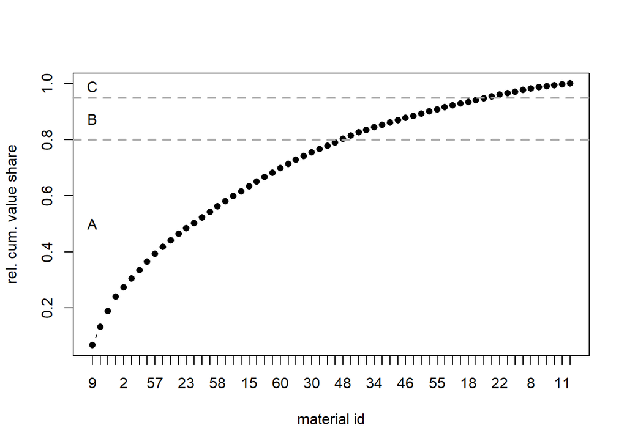

```r
# a plot
plot(1:n, rel.cum.val.vec.ord, type="b", xaxt = "n", pch =16, xlab = "material id", ylab = "rel. cum. value share")
axis(1, at = 1:n, labels = id.vec.ord)
abline(h = c(.8,.95), lwd=2, lty=2, col="darkgrey")
text(x = rep(1,3) , y = c(.5,.875,.99), labels = LETTERS[1:3] )
```

## IQR Analysis

Categorization by life cycle - Inventory quality ratio

Aim is to minimize the risk of obselensce.

- Life cycle of product $i$ is the change of demand over time.
- Variation of material with respect to it’s importance. Typically associated with ABC analysis.
- The higher the value of materials, the potential risk of obscelence situation. This risk increase if this are compared to it’s demand overstocked.

- $\hat w_i \Rightarrow$ estimated demand value per period (week).
- $s_i \Rightarrow$ The current stock value.
- $o_i \Rightarrow$The accepted turnover time of material $i \in I,$ then.

We will use these thresholds : A…2 per., B..4 per. and C..6 per.

1. Calculate active inventory $to_i = \hat w_i \cdot o_i$
2. Inventory quatlity ratio $IQR_i= $ the closer to 1, the better.

```r
n <- 62
set.seed(123456)
ave.stock.vec <- floor(stock.level)

o.vec <- as.factor(class.vec)
levels(o.vec) <- c(2,4,6)
o.vec <- as.numeric(as.character(o.vec))
names(o.vec) <- id.vec.ord

s.vec <- product_data$box_cost *ave.stock.vec
paste("Stock ",s.vec)
```

```
##  [1] "Stock  928.8"   "Stock  2547.2"  "Stock  1756"    "Stock  1756"
##  [5] "Stock  661.5"   "Stock  660"     "Stock  5565.56" "Stock  451.88"
##  [9] "Stock  5649.6"  "Stock  2948.4"  "Stock  192"     "Stock  945"
## [13] "Stock  2106.72" "Stock  1537.2"  "Stock  1001.7"  "Stock  729"
## [17] "Stock  724.8"   "Stock  729.6"   "Stock  3429"    "Stock  3235.2"
## [21] "Stock  257.4"   "Stock  724.8"   "Stock  2304"    "Stock  630"
## [25] "Stock  727.2"   "Stock  407.7"   "Stock  1787.4"  "Stock  3481.2"
## [29] "Stock  2275.2"  "Stock  747"     "Stock  1408.5"  "Stock  1881.6"
## [33] "Stock  3645"    "Stock  1065.6"  "Stock  2044.8"  "Stock  1359"
## [37] "Stock  639"     "Stock  645"     "Stock  411.4"   "Stock  604.8"
## [41] "Stock  1456"    "Stock  489.6"   "Stock  1528"    "Stock  941.2"
## [45] "Stock  553.8"   "Stock  608.4"   "Stock  544"     "Stock  912"
## [49] "Stock  1266"    "Stock  598.4"   "Stock  1108.8"  "Stock  900"
## [53] "Stock  648"     "Stock  1518"    "Stock  563.2"   "Stock  740"
## [57] "Stock  2217.6"  "Stock  1470"    "Stock  451.2"   "Stock  1202.4"
## [61] "Stock  258.75"  "Stock  117.75"
```

```r
toval.vec <- o.vec[as.character(1:n)]*(product_data$deman_per_day_boxes *5)* product_data$box_cost
paste("active Inve ",toval.vec)
```

```
##  [1] "active Inve  774"    "active Inve  7164"   "active Inve  1053.6"
##  [4] "active Inve  1053.6" "active Inve  1890"   "active Inve  180"
##  [7] "active Inve  5838"   "active Inve  1422"   "active Inve  2568"
## [10] "active Inve  5896.8" "active Inve  1152"   "active Inve  189"
## [13] "active Inve  957.6"  "active Inve  1281"   "active Inve  3339"
## [16] "active Inve  972"    "active Inve  1359"   "active Inve  1824"
## [19] "active Inve  2286"   "active Inve  2022"   "active Inve  2574"
## [22] "active Inve  1359"   "active Inve  768"    "active Inve  1575"
## [25] "active Inve  1212"   "active Inve  271.8"  "active Inve  397.2"
## [28] "active Inve  580.2"  "active Inve  948"    "active Inve  199.2"
## [31] "active Inve  187.8"  "active Inve  588"    "active Inve  1215"
## [34] "active Inve  1776"   "active Inve  340.8"  "active Inve  181.2"
## [37] "active Inve  1278"   "active Inve  1290"   "active Inve  1683"
## [40] "active Inve  1008"   "active Inve  2730"   "active Inve  183.6"
## [43] "active Inve  229.2"  "active Inve  217.2"  "active Inve  255.6"
## [46] "active Inve  1014"   "active Inve  204"    "active Inve  273.6"
## [49] "active Inve  126.6"  "active Inve  1122"   "active Inve  369.6"
## [52] "active Inve  900"    "active Inve  194.4"  "active Inve  151.8"
## [55] "active Inve  1056"   "active Inve  222"    "active Inve  924"
## [58] "active Inve  1470"   "active Inve  2538"   "active Inve  501"
## [61] "active Inve  3105"   "active Inve  1413"
```

```r
a.vec <- apply(cbind(s.vec, toval.vec),1 , min)
a.vec
```

```
##       1       2       3       4       5       6       7       8       9      10
##  774.00 2547.20 1053.60 1053.60  661.50  180.00 5565.56  451.88 2568.00 2948.40
##      11      12      13      14      15      16      17      18      19      20
##  192.00  189.00  957.60 1281.00 1001.70  729.00  724.80  729.60 2286.00 2022.00
##      21      22      23      24      25      26      27      28      29      30
##  257.40  724.80  768.00  630.00  727.20  271.80  397.20  580.20  948.00  199.20
##      31      32      33      34      35      36      37      38      39      40
##  187.80  588.00 1215.00 1065.60  340.80  181.20  639.00  645.00  411.40  604.80
##      41      42      43      44      45      46      47      48      49      50
## 1456.00  183.60  229.20  217.20  255.60  608.40  204.00  273.60  126.60  598.40
##      51      52      53      54      55      56      57      58      59      60
##  369.60  900.00  194.40  151.80  563.20  222.00  924.00 1470.00  451.20  501.00
##      61      62
##  258.75  117.75
```

```r
iqr.vec2 <- toval.vec/s.vec
e.vec <- s.vec - a.vec
e.vec
```

```
##       1       2       3       4       5       6       7       8       9      10
##  154.80    0.00  702.40  702.40    0.00  480.00    0.00    0.00 3081.60    0.00
##      11      12      13      14      15      16      17      18      19      20
##    0.00  756.00 1149.12  256.20    0.00    0.00    0.00    0.00 1143.00 1213.20
##      21      22      23      24      25      26      27      28      29      30
##    0.00    0.00 1536.00    0.00    0.00  135.90 1390.20 2901.00 1327.20  547.80
##      31      32      33      34      35      36      37      38      39      40
## 1220.70 1293.60 2430.00    0.00 1704.00 1177.80    0.00    0.00    0.00    0.00
##      41      42      43      44      45      46      47      48      49      50
##    0.00  306.00 1298.80  724.00  298.20    0.00  340.00  638.40 1139.40    0.00
##      51      52      53      54      55      56      57      58      59      60
##  739.20    0.00  453.60 1366.20    0.00  518.00 1293.60    0.00    0.00  701.40
##      61      62
##    0.00    0.00
```

```r
e.vec2 <- s.vec - toval.vec
e.vec2
```

```
##        1        2        3        4        5        6        7        8
##   154.80 -4616.80   702.40   702.40 -1228.50   480.00  -272.44  -970.12
##        9       10       11       12       13       14       15       16
##  3081.60 -2948.40  -960.00   756.00  1149.12   256.20 -2337.30  -243.00
##       17       18       19       20       21       22       23       24
##  -634.20 -1094.40  1143.00  1213.20 -2316.60  -634.20  1536.00  -945.00
##       25       26       27       28       29       30       31       32
##  -484.80   135.90  1390.20  2901.00  1327.20   547.80  1220.70  1293.60
##       33       34       35       36       37       38       39       40
##  2430.00  -710.40  1704.00  1177.80  -639.00  -645.00 -1271.60  -403.20
##       41       42       43       44       45       46       47       48
## -1274.00   306.00  1298.80   724.00   298.20  -405.60   340.00   638.40
##       49       50       51       52       53       54       55       56
##  1139.40  -523.60   739.20     0.00   453.60  1366.20  -492.80   518.00
##       57       58       59       60       61       62
##  1293.60     0.00 -2086.80   701.40 -2846.25 -1295.25
```

```r
tab <- data.frame("material.id" = 1:n, "stock.value" = round(s.vec,1), "to.value/act.inv" = round(toval.vec,1),  "iqr" = round(iqr.vec2,1), "excess.inv" = round(e.vec2,1))

kable(tab, digits = c(0,1,1,1,1),  caption = "Life-cycle analysis for materials 1-62", format = "pandoc")
```

Life-cycle analysis for materials 1-62

| material.id | stock.value | to.value.act.inv | iqr | excess.inv |
| --- | --- | --- | --- | --- |
| 1 | 928.8 | 774.0 | 0.8 | 154.8 |
| 2 | 2547.2 | 7164.0 | 2.8 | -4616.8 |
| 3 | 1756.0 | 1053.6 | 0.6 | 702.4 |
| 4 | 1756.0 | 1053.6 | 0.6 | 702.4 |
| 5 | 661.5 | 1890.0 | 2.9 | -1228.5 |
| 6 | 660.0 | 180.0 | 0.3 | 480.0 |
| 7 | 5565.6 | 5838.0 | 1.0 | -272.4 |
| 8 | 451.9 | 1422.0 | 3.1 | -970.1 |
| 9 | 5649.6 | 2568.0 | 0.5 | 3081.6 |
| 10 | 2948.4 | 5896.8 | 2.0 | -2948.4 |
| 11 | 192.0 | 1152.0 | 6.0 | -960.0 |
| 12 | 945.0 | 189.0 | 0.2 | 756.0 |
| 13 | 2106.7 | 957.6 | 0.5 | 1149.1 |
| 14 | 1537.2 | 1281.0 | 0.8 | 256.2 |
| 15 | 1001.7 | 3339.0 | 3.3 | -2337.3 |
| 16 | 729.0 | 972.0 | 1.3 | -243.0 |
| 17 | 724.8 | 1359.0 | 1.9 | -634.2 |
| 18 | 729.6 | 1824.0 | 2.5 | -1094.4 |
| 19 | 3429.0 | 2286.0 | 0.7 | 1143.0 |
| 20 | 3235.2 | 2022.0 | 0.6 | 1213.2 |
| 21 | 257.4 | 2574.0 | 10.0 | -2316.6 |
| 22 | 724.8 | 1359.0 | 1.9 | -634.2 |
| 23 | 2304.0 | 768.0 | 0.3 | 1536.0 |
| 24 | 630.0 | 1575.0 | 2.5 | -945.0 |
| 25 | 727.2 | 1212.0 | 1.7 | -484.8 |
| 26 | 407.7 | 271.8 | 0.7 | 135.9 |
| 27 | 1787.4 | 397.2 | 0.2 | 1390.2 |
| 28 | 3481.2 | 580.2 | 0.2 | 2901.0 |
| 29 | 2275.2 | 948.0 | 0.4 | 1327.2 |
| 30 | 747.0 | 199.2 | 0.3 | 547.8 |
| 31 | 1408.5 | 187.8 | 0.1 | 1220.7 |
| 32 | 1881.6 | 588.0 | 0.3 | 1293.6 |
| 33 | 3645.0 | 1215.0 | 0.3 | 2430.0 |
| 34 | 1065.6 | 1776.0 | 1.7 | -710.4 |
| 35 | 2044.8 | 340.8 | 0.2 | 1704.0 |
| 36 | 1359.0 | 181.2 | 0.1 | 1177.8 |
| 37 | 639.0 | 1278.0 | 2.0 | -639.0 |
| 38 | 645.0 | 1290.0 | 2.0 | -645.0 |
| 39 | 411.4 | 1683.0 | 4.1 | -1271.6 |
| 40 | 604.8 | 1008.0 | 1.7 | -403.2 |
| 41 | 1456.0 | 2730.0 | 1.9 | -1274.0 |
| 42 | 489.6 | 183.6 | 0.4 | 306.0 |
| 43 | 1528.0 | 229.2 | 0.2 | 1298.8 |
| 44 | 941.2 | 217.2 | 0.2 | 724.0 |
| 45 | 553.8 | 255.6 | 0.5 | 298.2 |
| 46 | 608.4 | 1014.0 | 1.7 | -405.6 |
| 47 | 544.0 | 204.0 | 0.4 | 340.0 |
| 48 | 912.0 | 273.6 | 0.3 | 638.4 |
| 49 | 1266.0 | 126.6 | 0.1 | 1139.4 |
| 50 | 598.4 | 1122.0 | 1.9 | -523.6 |
| 51 | 1108.8 | 369.6 | 0.3 | 739.2 |
| 52 | 900.0 | 900.0 | 1.0 | 0.0 |
| 53 | 648.0 | 194.4 | 0.3 | 453.6 |
| 54 | 1518.0 | 151.8 | 0.1 | 1366.2 |
| 55 | 563.2 | 1056.0 | 1.9 | -492.8 |
| 56 | 740.0 | 222.0 | 0.3 | 518.0 |
| 57 | 2217.6 | 924.0 | 0.4 | 1293.6 |
| 58 | 1470.0 | 1470.0 | 1.0 | 0.0 |
| 59 | 451.2 | 2538.0 | 5.6 | -2086.8 |
| 60 | 1202.4 | 501.0 | 0.4 | 701.4 |
| 61 | 258.8 | 3105.0 | 12.0 | -2846.2 |
| 62 | 117.8 | 1413.0 | 12.0 | -1295.2 |

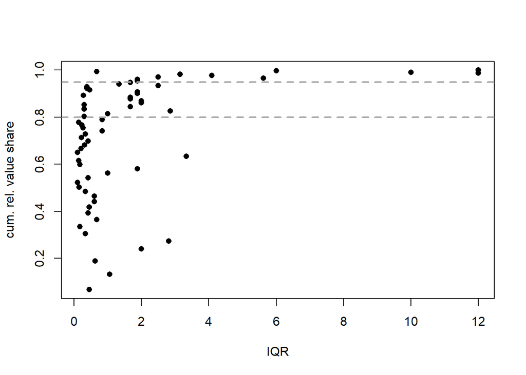

```r
names(iqr.vec2) <- 1:n

names(rel.cum.val.vec.ord)<- id.vec.ord

{plot(iqr.vec2 , rel.cum.val.vec.ord[as.character(1:n)] , xlab="IQR", pch=16, ylab="cum. rel. value share")
abline(h=c(.8, .95), lty=2, lwd=2, col="darkgrey")
text(x = c(60,rep(100,3)) , y = c(0.2,.5,.875,.99), labels = c("fast mover", LETTERS[1:3]) )}
```